# European countries, their dietary habits and diabetes prevalence

Alesya Alpbaz,Clara Nessi and Fabien Calderini

16.12.2021

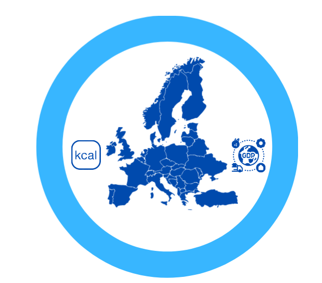

# 1 Introduction

## 1.1 Overview and Motivation

During the last 2 years, COVID-19 has been a main focus of the news. Though around 3% of the world population had COVID-19, diabetes can be considered as an even bigger health problem. Indeed, according to the International Diabetes Foundations (IDF), in 2019, 463 million adults were living with diabetes (around 6-7% of the world population) and this number is forecasted to rise to 700 million by 2050. Furthermore, 90% of cases of diabetes are of type 2, which means it results mainly from bad habits and not genetics. However both types of diabetes can be treated and/or prevented with a healthier diet and more physical activity. Additionally, according to the WHO, low income countries are more susceptible to having higher diabetes prevalence. Living in Europe, we observed that diabetes rates differ a lot from one country to another, so we wanted to find out if these rates were indeed linked to a country’s income, and if the nutritious composition of richer states’ population’s diet is also affected by this income difference and if yes, how it is affected.

## 1.2 Related Work

The article published by M. Adeva-Andany (2019) “Dietary habits contribute to define the risk of type 2 diabetes in humans” states that type 2 diabetes could be prevented by better dietary habits.They also found that higher animal protein consumption induced a greater risk of developing type 2 diabetes regardless of body mass index. In addition, they have also said that: “Low intake of animal products is linked to high educational level so that well-informed individuals tend to consume diets with elevated content of vegetable food” which can be linked to the GDP. (https://www.sciencedirect.com/science/article/pii/S240545771930419X?casa_token=Dzx3S9e8WgsAAAAA:IUYCy_uePTCOLUn38QUDO5KtpJopGpHdNIXZtHVVsGy9NWuXQ78Hp2juTvtjFQp67Dk2by-fMgPfrg)

## 1.3 Research questions

Therefore, we would like to find out answers to the following questions :

1. Do European countries that have higher GDPs really have lower diabetes prevalence ?
2. Do European countries that have higher GDPs consume less calories ?
3. How do the proportions of macronutrients (animal protein/plant protein/fat/carbohydrates) consumed differ between richer and poorer governments ?
4. And how do these differences relate to the diabetes prevalence in these countries ? What is the typical diet that can be observed in richer states that relates to lower diabetes prevalence ?

# 2 Data

To answer our research questions, we used three different datasets. While searching for datasets, we made sure that the years and countries matched for every one of them.

## 2.1 Wrangling and cleaning

### 2.1.1 Caloric consumption

The first dataset we used, downloaded from the portal https://ourworldindata.org/diet-compositions, contains information related to the supply of macronutrients in calories for different countries. We used data related to food supply rather than food consumption, as the latter is harder to find and generally, supply reflects the population’s demand and therefore its food consumption. The dataset gives us information on the average nutrition of different countries from 1961 to 2013 :

- It is composed of 8981 observations of 7 variables:
  - `Entity` Name of the country
  - `Code` ISO country code
  - `Year`Year of the observation
  - `Calories from animal protein (FAO (2017))` The average per capita supply of calories derived from animal protein all measured in kilocalories per person per day
  - `Calories from plant protein (FAO (2017))` The average per capita supply of calories derived from plant protein, all measured in kilocalories per person per day
  - `Calories from fat (FAO (2017))`The average per capita supply of calories derived from fat, all measured in kilocalories per person per day
  - `Calories from carbohydrates (FAO (2017))` The average per capita supply of calories derived from carbohydrates, all measured in kilocalories per person per day

The intake of specific macronutrients (carbohydrates, protein and fats) are derived based on average food composition factors – these factors are derived and presented in the Food and Agriculture Organisation’s (FAO) Food Balance Sheet Handbook (https://www.fao.org/faostat/en/#data).

We will only focus on observations of European countries in the 2000s.

We used the ISO code as it is standardized worldwide and does not have the risk of having different names in different tables like the countries’ names.

Then, we proceeded to compute the mean of the consumption for each type of macronutrient in each country between the years 2000 and 2013, and the sum of total calories per person per day for each country in order to answer our second research question.

We then created a new table by adding the sum of total calories per person per day for each country in order to get a broader view with the total consumption of calories. To make sure that the joining of tables go smoothly, we also removed duplicates and the country name column.

Our assumption was that a county’s wealth may fluctuate over the course of 10 years (ex: a dip during the economic crisis of 2008) but an overall mean is sufficient to compare the different countries and their riches.

- We now have a dataframe with the following variables :
  - `country_code` ISO country code
  - `cal_prot_animal`The mean of the calories from animal protein consumed per person in each country in the years 2000-2013
  - `cal_prot_plant` The mean of the calories from plant protein consumed per person in each country in the years 2000-2013
  - `cal_carbs`The mean of the calories from carbohydrates consumed per person in each country in the years 2000-2013
  - `cal_fat` The mean of the calories from fat consumed per person in each country in the years 2000-2013
  - `total_consumption` The total calorie consumption per person based on the means of the consumption of each type of macronutrients in each countries in the years 2000-2013

The final table is the following:

**Table 1**: Caloric Consumption

| Country Code | Calories from animal protein | Calories from plant protein | Calories from carbohydrates | Calories from fat | Total consumption |
| --- | --- | --- | --- | --- | --- |
| AUT | 245 | 169 | 1833 | 1454 | 3702 |
| BEL | 238 | 158 | 1856 | 1467 | 3719 |
| BGR | 155 | 168 | 1606 | 846 | 2775 |
| HRV | 168 | 148 | 1691 | 940 | 2946 |
| CYP | 197 | 127 | 1291 | 1019 | 2633 |
| CZE | 218 | 153 | 1728 | 1155 | 3254 |
| DNK | 273 | 157 | 1746 | 1190 | 3366 |
| EST | 212 | 167 | 1967 | 842 | 3188 |
| FIN | 269 | 166 | 1623 | 1177 | 3234 |
| FRA | 293 | 161 | 1611 | 1480 | 3545 |
| DEU | 240 | 159 | 1785 | 1276 | 3460 |
| GRC | 250 | 204 | 1744 | 1338 | 3536 |
| HUN | 193 | 153 | 1560 | 1221 | 3126 |
| IRL | 279 | 174 | 1950 | 1187 | 3590 |
| ITA | 241 | 204 | 1776 | 1390 | 3612 |
| LVA | 203 | 154 | 1687 | 1044 | 3087 |
| LTU | 274 | 198 | 2055 | 858 | 3385 |
| LUX | 288 | 148 | 1752 | 1318 | 3507 |
| MLT | 237 | 204 | 1932 | 994 | 3367 |
| NLD | 292 | 136 | 1599 | 1195 | 3222 |
| POL | 204 | 197 | 1969 | 1035 | 3405 |
| PRT | 275 | 177 | 1824 | 1240 | 3516 |
| ROU | 200 | 220 | 2003 | 916 | 3340 |
| SVK | 140 | 150 | 1610 | 952 | 2853 |
| SVN | 230 | 168 | 1664 | 1067 | 3129 |
| ESP | 279 | 159 | 1481 | 1323 | 3243 |
| SWE | 285 | 143 | 1566 | 1137 | 3131 |
| CHE | 237 | 138 | 1660 | 1392 | 3426 |
| GBR | 232 | 178 | 1748 | 1256 | 3414 |

### 2.1.2 GDP

Our second dataset, downloaded from the portal https://data.worldbank.org, gives us information about the GDP of many countries over the course of 60 years (1960-2020).

- It is composed of 266 observations of 65 variables :
  - `Country Name` Name of the country
  - `Country Code` ISO country code
  - `Indicator Name` equal to “GDP in current US$” for every row
  - `Indicator Code` equal to “NY.GDP.MKTP.CD” for every row
  - And a variable for each year from 1960 to 2020

We decided to fix that and to filter out the years that is in our interest and that we have in common with other tables, so the years 2000-2013. We decided to get rid of the `Indicator Name` and `Indicator Code` variables as well since the values are the same for every row and they do not provide additional useful information.

Now, we want to filter out the European countries, just like in the first table :

In order to join tables easily, we transformed the columns corresponding to different years to a single “year” column, in order to have at each row of this dataset the GDP of a certain country at a certain year.

To make it easier to manipulate data, we decided to rename our variables for this table as well. We also made sure that the type of our numeric variable (GDP) was numeric and not character, like it was by default. In order to have graphs that are easy to read in the exploratory data analysis, we also decided to divide the `avg_gdp` column by a billion.

Lastly, we computed the average GDP for each country over the years 2000-2013 in order to be able to plot different variables together.

**Table 2**: GDP

| Country Name | Country Code | Average GDP (in billion $) |
| --- | --- | --- |
| Austria | AUT | 335.98 |
| Belgium | BEL | 406.97 |
| Bulgaria | BGR | 37.41 |
| Croatia | HRV | 48.12 |
| Cyprus | CYP | 20.15 |
| Czech Republic | CZE | 158.48 |
| Denmark | DNK | 275.37 |
| Estonia | EST | 16.47 |
| Finland | FIN | 216.58 |
| France | FRA | 2283.48 |
| Germany | DEU | 3003.51 |
| Greece | GRC | 246.19 |
| Hungary | HUN | 110.92 |
| Ireland | IRL | 203.04 |
| Italy | ITA | 1872.80 |
| Latvia | LVA | 21.04 |
| Lithuania | LTU | 30.77 |
| Luxembourg | LUX | 42.85 |
| Malta | MLT | 7.27 |
| Netherlands | NLD | 721.70 |
| Poland | POL | 365.43 |
| Portugal | PRT | 200.37 |
| Romania | ROU | 125.08 |
| Slovak Republic | SVK | 70.82 |
| Slovenia | SVN | 39.50 |
| Spain | ESP | 1176.91 |
| Sweden | SWE | 425.83 |
| Switzerland | CHE | 490.18 |
| United Kingdom | GBR | 2416.76 |

We now have a dataframe with the following variables :

- `country_name` name of the country
- `country_code` ISO code of the country
- `avg_gdp` the average GDP of a country over the course of 2000-2013

#### 2.1.2.1 Population

Since we will be observing the relation between the GDP with the calories consumed per person, it could be useful to have the GDP per person for the analysis. This is why we will be importing this dataset from https://data.worldbank.org/indicator/SP.POP.TOTL which gives us information on the evolution of the population per country over 1960-2020.

- It is composed of 266 observations of 65 variables :
  - `Country Name` Name of the country
  - `Country Code` ISO country code
  - `Indicator Name` equal to “Population, total” for every row
  - `Indicator Code` equal to “SP.POP.TOTL” for every row
  - And a variable for each year from 1960 to 2020

As this dataset comes from the same source and is the same file type as GDP, we can proceed with the same wrangling

In order to analyze the link between the GDP per person and calorie consumption per person, we will create a separate table which we will join to the final clean dataset.

We now have a dataframe with the following variables :

- `country_name` name of the country
- `country_code` ISO code of the country
- `gdp_per_person` the average GDP per person of a country over the course of 2000-2013

### 2.1.3 Diabetes

The third dataset, downloaded from https://www.ncdrisc.org/data-downloads-diabetes.html, gives us information about the age-standardised diabetes prevalence for each country and gender from 1980 to 2014.

- It is composed of 14’000 observations for 7 variables :
  - `Country/Region/World` Name of the country
  - `ISO` ISO country code
  - `Sex` Gender for which the diabetes prevalence is measured in a certain country at a certain year
  - `Year` Year of observation (1980-2014)
  - `Age-standardised diabetes prevalence` Diabetes rate considering all ages
  - `Lower 95% uncertainty interval` Lower confidence interval limit for the diabetes rate
  - `Upper 95% uncertainty interval` Higher confidence interval limit for the diabetes rate

Like with the first 2 datasets, we filtered our data to keep only European countries and observations between the years 2000 and 2013.

We also decided not to use the 95% confidence interval variable.

Then, we separated our dataset into two subsets. One with data about men.

Another one with data about women.

We then changed the variable names of these 2 subsets to facilitate joining tables later on.

Finally we grouped observations by country to get the mean prevalence/rate of diabetes between 2000 and 2013 for each European country :

- For men :

**Table 3**: Diabetes rates for men

| Country Code | Diabetes rate |
| --- | --- |
| AUT | 0.053 |
| BEL | 0.057 |
| BGR | 0.073 |
| CHE | 0.050 |
| CYP | 0.077 |
| CZE | 0.078 |
| DEU | 0.059 |
| DNK | 0.055 |
| ESP | 0.084 |
| EST | 0.071 |
| FIN | 0.066 |
| FRA | 0.071 |
| GBR | 0.063 |
| GRC | 0.069 |
| HRV | 0.071 |
| HUN | 0.080 |
| IRL | 0.069 |
| ITA | 0.065 |
| LTU | 0.078 |
| LUX | 0.068 |
| LVA | 0.071 |
| MLT | 0.088 |
| NLD | 0.052 |
| POL | 0.074 |
| PRT | 0.075 |
| ROU | 0.062 |
| SVK | 0.072 |
| SVN | 0.066 |
| SWE | 0.058 |

- For women :

**Table 4**: Diabetes rates for women

[output not shown]

We now have 2 dataframes with the following variables :

- `country_code` ISO code of the country
- `prop_men_diabetes` or `prop_women_diabetes`the average diabetes rate in a country in the 2000-2013 timeframe

## 2.2 Joining tables

For the last step of our tidying, we joined all four tables in one dataset with the `country_code` key :

**Table 5**: Joint table for GDP, diabetes and caloric consumption

| Country Name | Country Code | Average GDP (in billion $) | GDP per person (in $) | Men Diabetes | Women Diabetes | Calories from animal protein | Calories from plant protein | Calories from carbohydrates | Calories from fat | Total consumption |
| --- | --- | --- | --- | --- | --- | --- | --- | --- | --- | --- |
| Austria | AUT | 335.98 | 40545 | 0.053 | 0.034 | 245 | 169 | 1833 | 1454 | 3702 |
| Belgium | BEL | 406.97 | 38015 | 0.057 | 0.039 | 238 | 158 | 1856 | 1467 | 3719 |
| Bulgaria | BGR | 37.41 | 4988 | 0.073 | 0.064 | 155 | 168 | 1606 | 846 | 2775 |
| Croatia | HRV | 48.12 | 11189 | 0.071 | 0.059 | 168 | 148 | 1691 | 940 | 2946 |
| Cyprus | CYP | 20.15 | 18890 | 0.077 | 0.056 | 197 | 127 | 1291 | 1019 | 2633 |
| Czech Republic | CZE | 158.48 | 15283 | 0.078 | 0.065 | 218 | 153 | 1728 | 1155 | 3254 |
| Denmark | DNK | 275.37 | 50213 | 0.055 | 0.035 | 273 | 157 | 1746 | 1190 | 3366 |
| Estonia | EST | 16.47 | 12283 | 0.071 | 0.064 | 212 | 167 | 1967 | 842 | 3188 |
| Finland | FIN | 216.58 | 40806 | 0.066 | 0.044 | 269 | 166 | 1623 | 1177 | 3234 |
| France | FRA | 2283.48 | 35700 | 0.071 | 0.044 | 293 | 161 | 1611 | 1480 | 3545 |
| Germany | DEU | 3003.51 | 36733 | 0.059 | 0.040 | 240 | 159 | 1785 | 1276 | 3460 |
| Greece | GRC | 246.19 | 22344 | 0.069 | 0.060 | 250 | 204 | 1744 | 1338 | 3536 |
| Hungary | HUN | 110.92 | 11050 | 0.080 | 0.063 | 193 | 153 | 1560 | 1221 | 3126 |
| Ireland | IRL | 203.04 | 46899 | 0.069 | 0.049 | 279 | 174 | 1950 | 1187 | 3590 |
| Italy | ITA | 1872.80 | 32000 | 0.065 | 0.047 | 241 | 204 | 1776 | 1390 | 3612 |
| Latvia | LVA | 21.04 | 9774 | 0.071 | 0.065 | 203 | 154 | 1687 | 1044 | 3087 |
| Lithuania | LTU | 30.77 | 9697 | 0.078 | 0.069 | 274 | 198 | 2055 | 858 | 3385 |
| Luxembourg | LUX | 42.85 | 87546 | 0.068 | 0.039 | 288 | 148 | 1752 | 1318 | 3507 |
| Malta | MLT | 7.27 | 17759 | 0.088 | 0.066 | 237 | 204 | 1932 | 994 | 3367 |
| Netherlands | NLD | 721.70 | 43883 | 0.052 | 0.037 | 292 | 136 | 1599 | 1195 | 3222 |
| Poland | POL | 365.43 | 9586 | 0.074 | 0.066 | 204 | 197 | 1969 | 1035 | 3405 |
| Portugal | PRT | 200.37 | 19077 | 0.075 | 0.052 | 275 | 177 | 1824 | 1240 | 3516 |
| Romania | ROU | 125.08 | 6062 | 0.062 | 0.059 | 200 | 220 | 2003 | 916 | 3340 |
| Slovak Republic | SVK | 70.82 | 13146 | 0.072 | 0.059 | 140 | 150 | 1610 | 952 | 2853 |
| Slovenia | SVN | 39.50 | 19502 | 0.066 | 0.065 | 230 | 168 | 1664 | 1067 | 3129 |
| Spain | ESP | 1176.91 | 26263 | 0.084 | 0.059 | 279 | 159 | 1481 | 1323 | 3243 |
| Sweden | SWE | 425.83 | 46181 | 0.058 | 0.040 | 285 | 143 | 1566 | 1137 | 3131 |
| Switzerland | CHE | 490.18 | 64036 | 0.050 | 0.030 | 237 | 138 | 1660 | 1392 | 3426 |
| United Kingdom | GBR | 2416.76 | 39338 | 0.063 | 0.049 | 232 | 178 | 1748 | 1256 | 3414 |

## 2.3 Missing values

We did not have any NA values in our tables, we think this is due to the fact that we really spent time on gathering quality data that matched in terms of dates and countries.

# 3 Exploratory data analysis

First, even though we will be taking the means of the variables with which we are trying to answer our questions, it is interesting to observe their evolution in each country over time. We started with the GDP.

## 3.1 Evolution of GDP per country

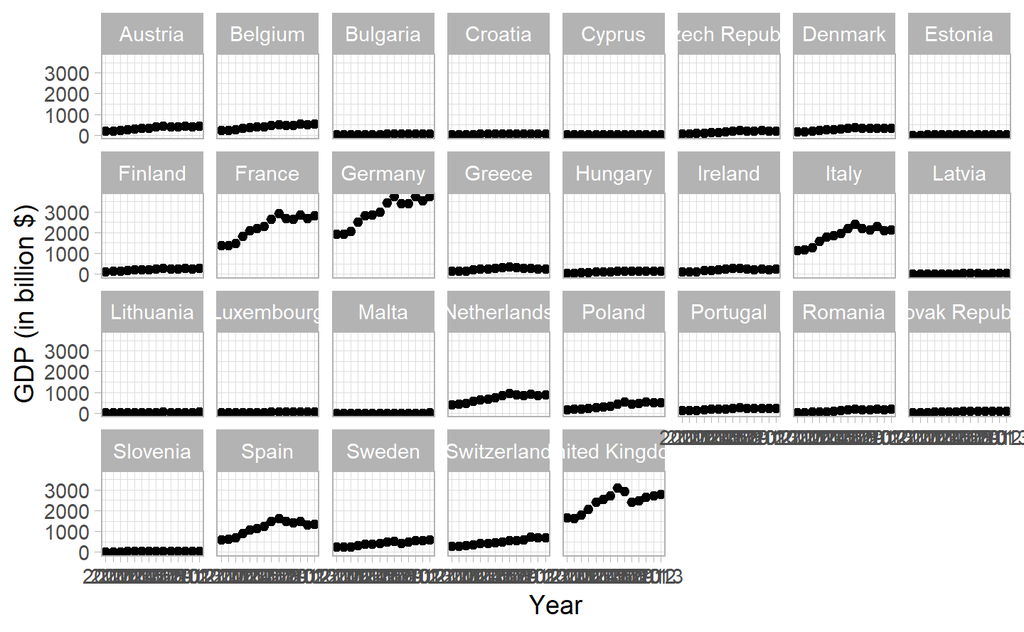

We can see that the GDP of France, Germany, Italy, Spain and the United Kingdom had a significant increase between 2000 and 2008.

## 3.2 Plotting GDP against Diabetes (Men & Women)

Now let’s see if there is a relation between the GDP of a country and its diabetes prevalence. (men = blue, women = red)

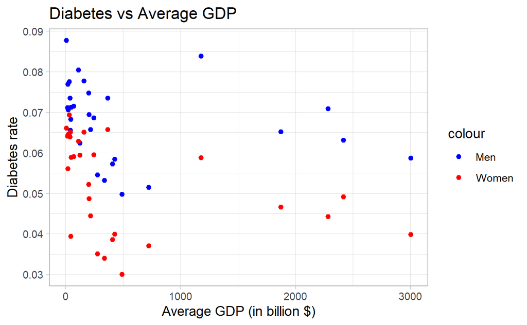

We observe that apart of 5 outliers, our observations are mostly bunched up at the left of the graph. We decided to exclude these 5 observations, to see if we can observe a trend with the other countries. These outliers, as we can see on the graph before, are the countries that had a big increase of GDP in the time period of 2000-2013.

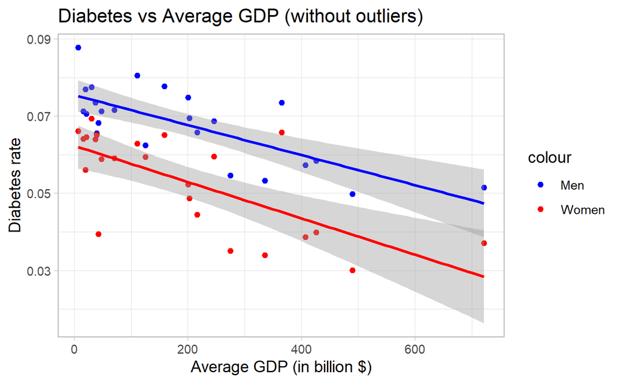

Without the outliers, we can see a bit more clearly. Indeed, it seems that the richer a country is, the lesser it has a high diabetes rate among its population.

## 3.3 Evolution of the consumption of macronutrients in calories per country

For the second table, we tried to see again if there was a trend in the consumption of different macro-nutrients in the 2000s for each country in our sample. We observed that in different countries, there is one difference that stands out and that seems to be related to wealth. Indeed, countries with a higher GDP like Austria consume on average more fat as can be seen on this graph:

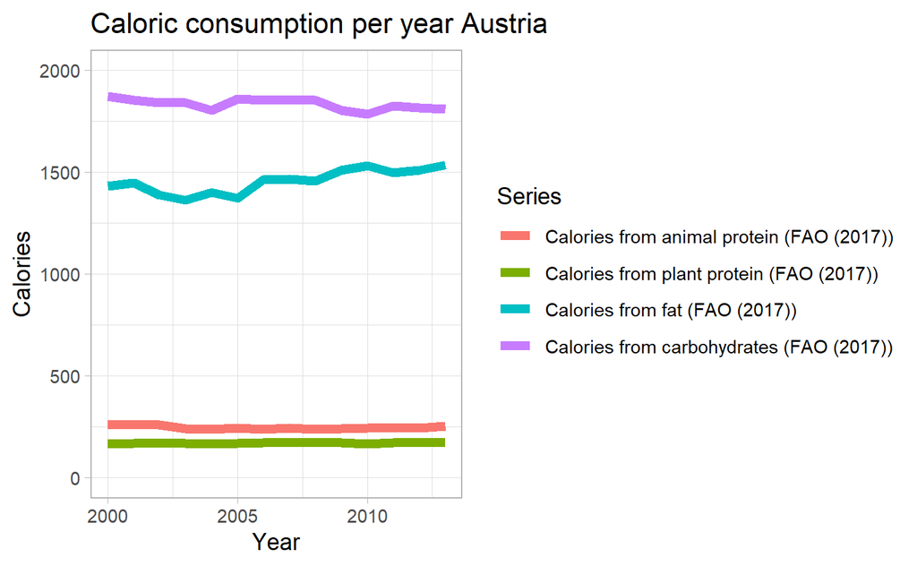

Whereas, countries with a lower GDP like Bulgaria have a lower fat consumption, as seen below:

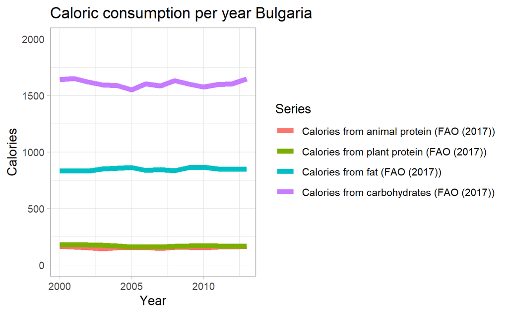

There do not seem to be any trends in the graphs above and diets seem rather stable in each country, which is why we will take the average consumption for each macro-nutrient for our analysis. We can however note that the 5 outliers mentioned before tend to have a higher fat consumption than the countries with a smaller GDP.

## 3.4 Plotting GDP against calories consumed

We then wanted to analyse the relation between a country’s GDP and its individual consumption of each macronutrient as well as its total calorie consumption to see if there’s a trend.

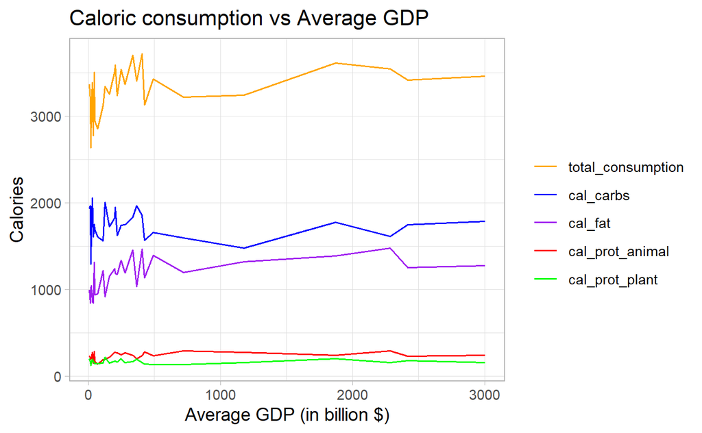

We see that the calorie consumption does not really change. We wanted a close up on the relation between the total calorie consumption with the GDP for each country to see if we can spot outliers again, so we created other plots.

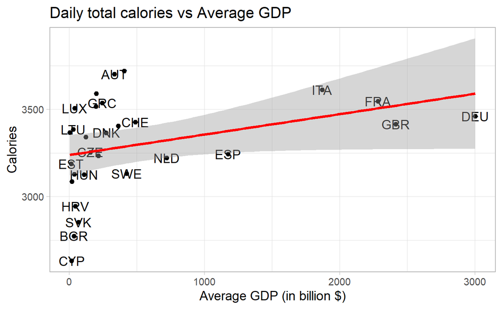

We end up again with these 5 outliers that have a higher than average GDP so if we remove them, we obtain the following plots :

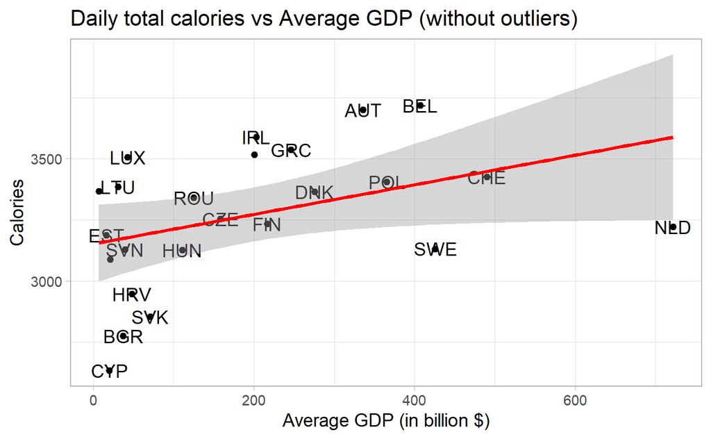

Now we can more easily state that there’s a trend. It appears that the higher a country’s GDP, the higher the total calories consumed, contrary to our hypothesis.

## 3.5 Evolution of Diabetes per country

Once again, we tried to see if the diabetes prevalence in each country changed over the years 2000-2013. We saw right away that the prevalence of diabetes is higher for man than women across all countries (there are however two exceptions : in Romania between 2000 and 2003 and Slovenia between 2000 and 2006).

We observed three different scenarios for countries that we selected: A decrease of diabetes over time for:

- Belgium
- Denmark
- Finland

We take Belgium as an example :

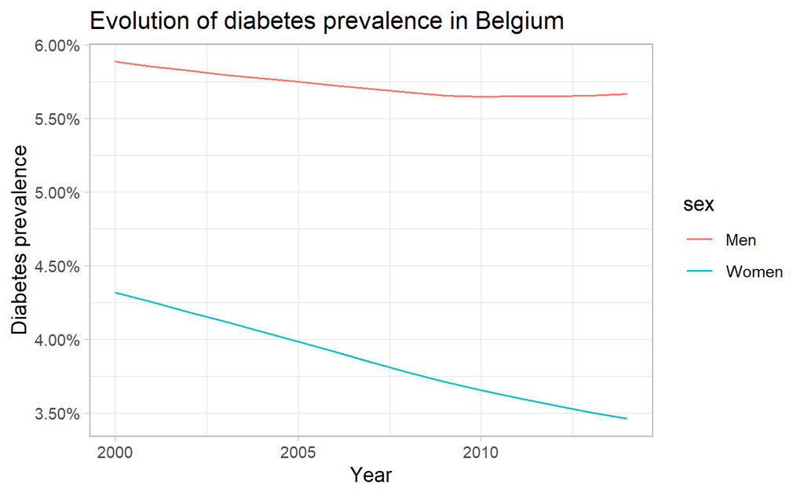

A decrease over time for women but not for men for :

- Austria
- Malta
- Netherlands
- Germany
- Italy
- Spain
- Switzerland

We take Austria as an example :

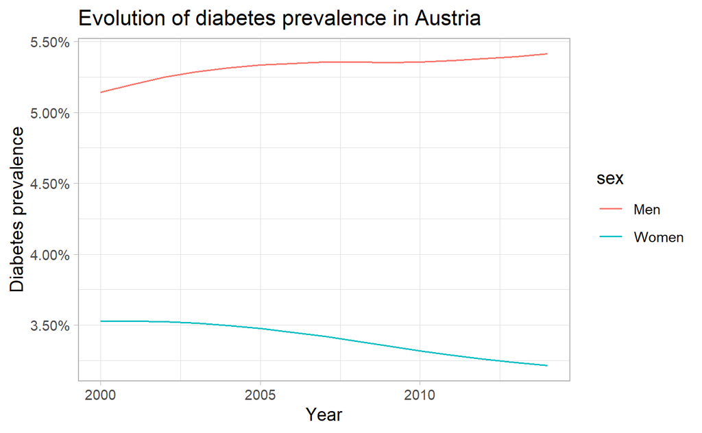

In other European countries, the prevalence of diabetes is increasing (at different paces) over time.

We take Croatia as an example :

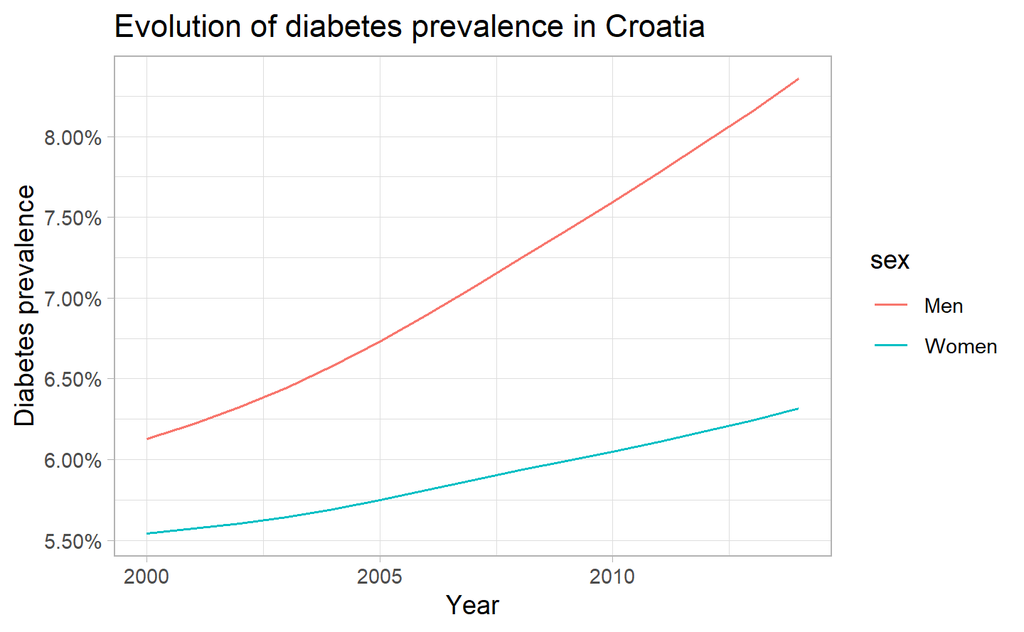

## 3.6 Plotting Diabetes against each type of macronutrient consumption

Finally, we want to plot the relation between the diabetes prevalence against the total calorie consumption as well as each type of macronutrient consumed.

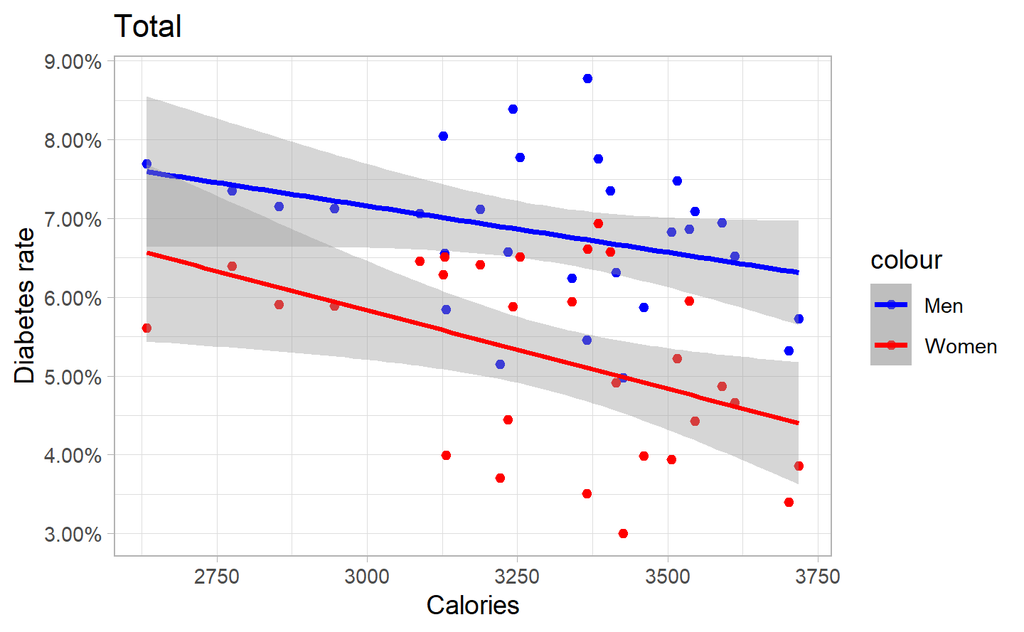

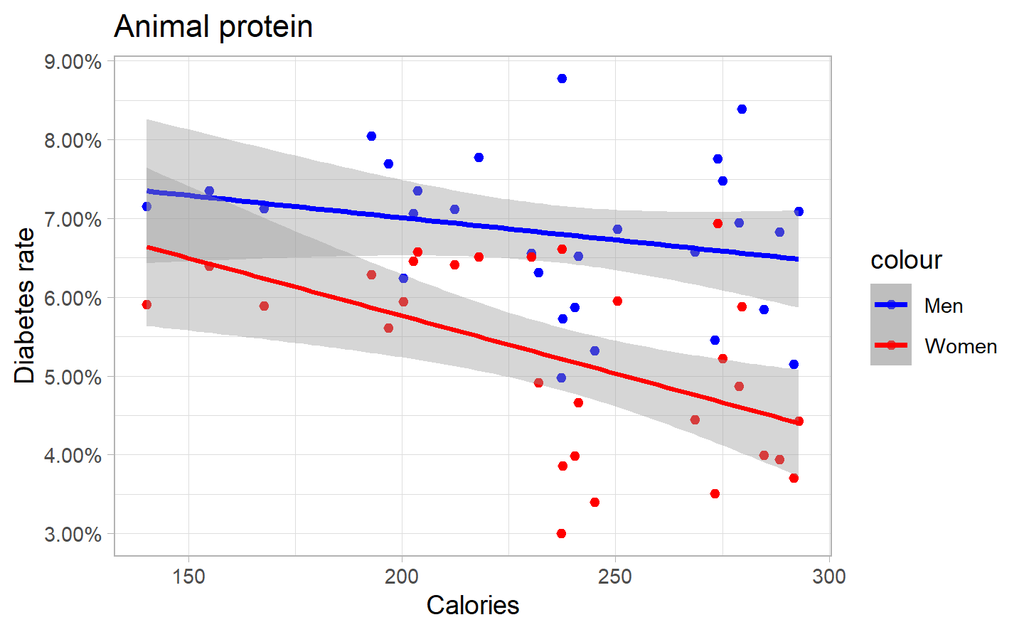

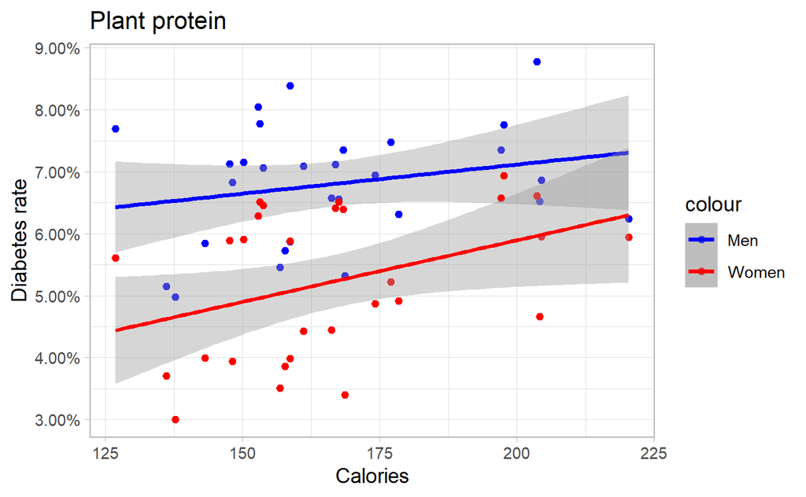

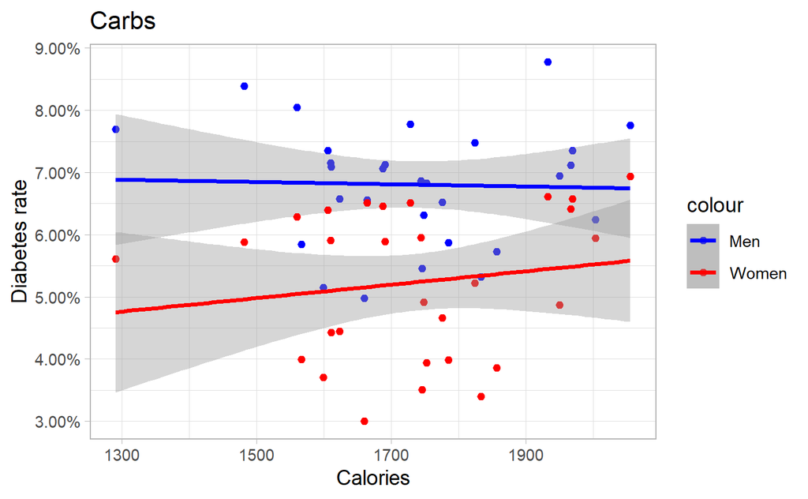

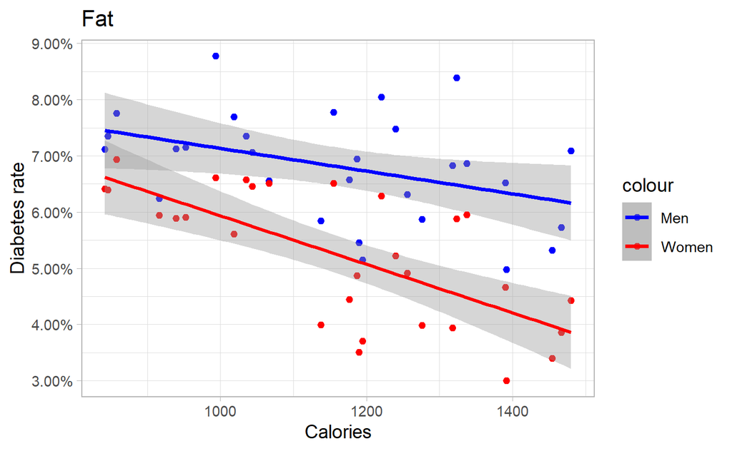

We can see a negative trend for the total consumption, the calories from animal protein and the calories from fat. We can observe a positive trend against calories from plant protein. For protein from carbohydrates, we can see a slighty positive trend for women.

## 3.7 Plotting Diabetes against each type of macronutrient consumption (without outliers)

Now, since they affected our plots that included the GDP variable so much, we want to see if we have different trends when we remove our 5 outliers.

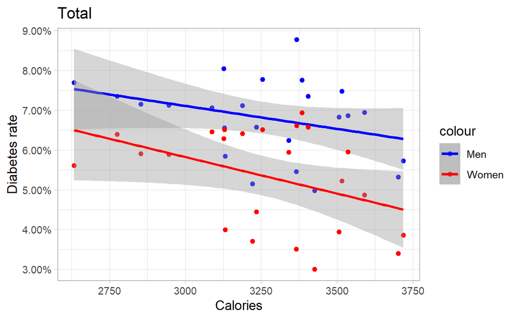

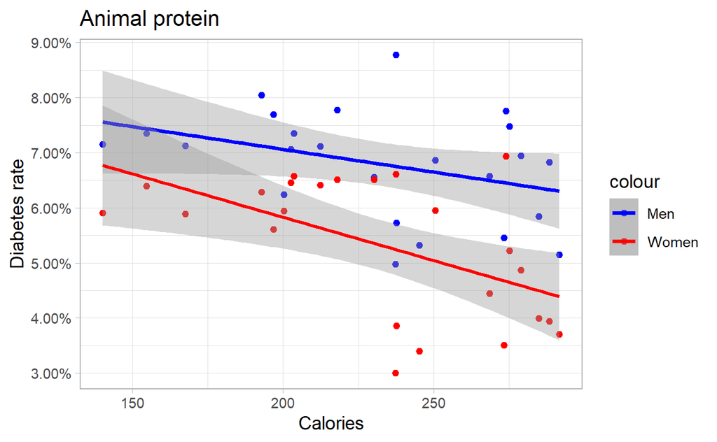

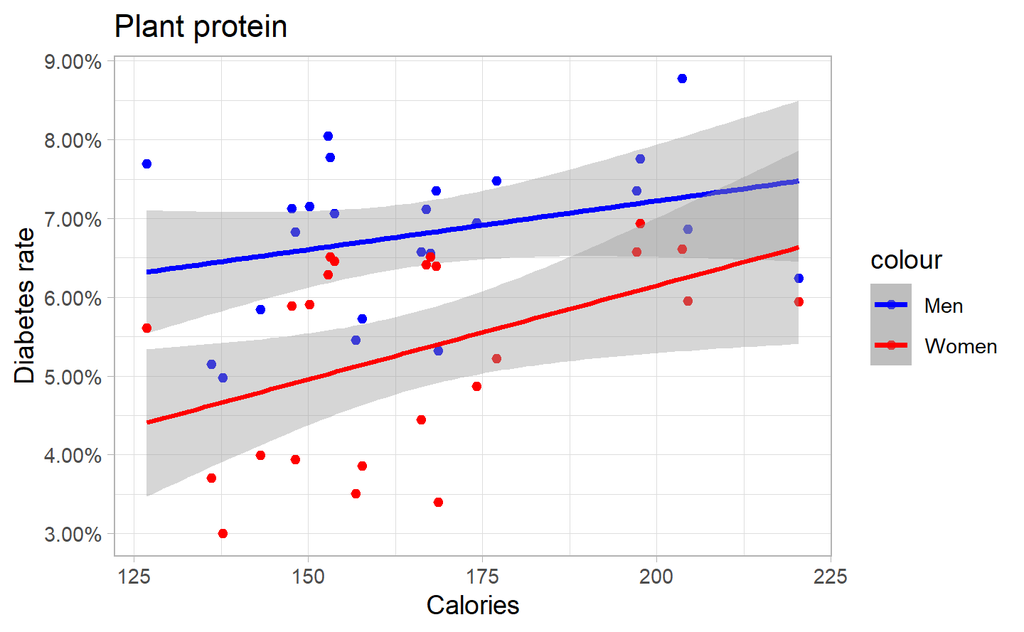

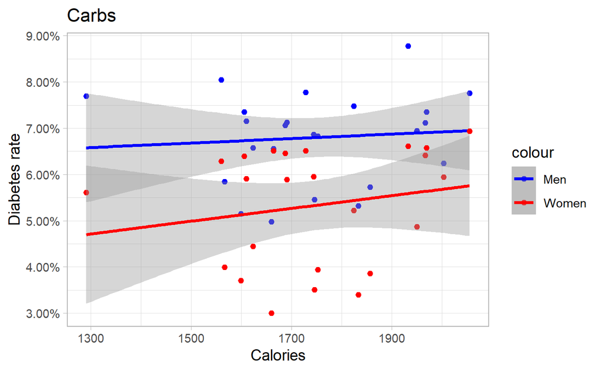

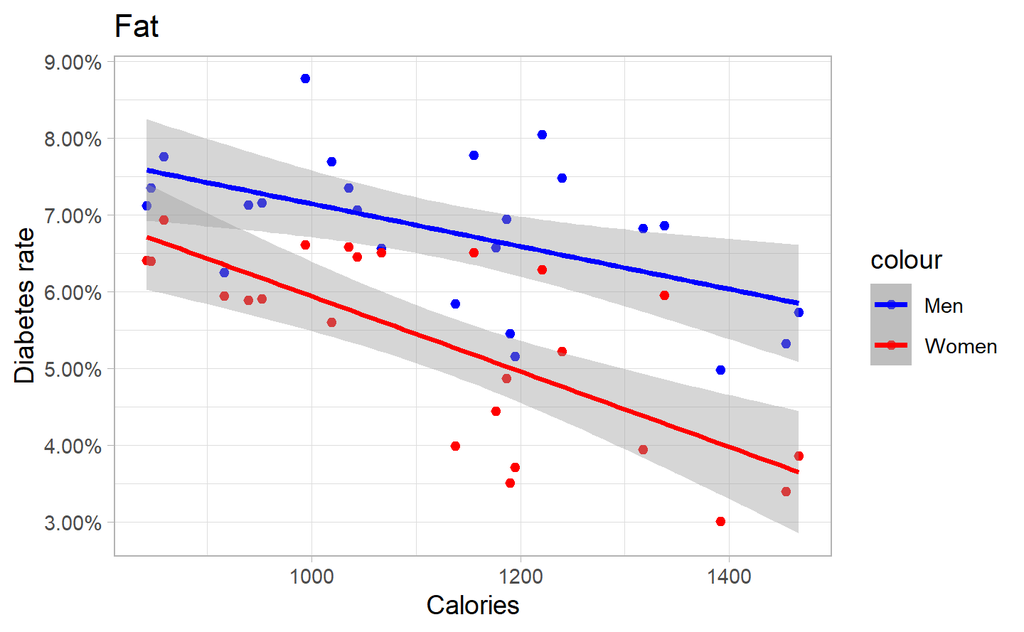

Without our 5 outliers, we observe not much change in the trend of each type of calories consumed apart for carbohydrates where the trend changes for men and become slightly positive.

# 4 Analysis

## 4.1 Do European countries that have higher GDPs really have lower diabetes prevalence ?

This first question serves more as a control, since we learned during our research prior to our project that countries with higher GDPs tend to have lower diabetes rates. Indeed, we can observe that in the EDA.

**Correlation (with outliers)**

| Between average GDP and women diabetes rate | -0.369 |
| --- | --- |
| Between average GDP and men diabetes rate | -0.236 |

|  | Average GDP vs Women diabetes rate |  |  |  |
| --- | --- | --- | --- | --- |
| Predictors | Estimates | std. Error | Statistic | p |
| (Intercept) | 1847.35 | 654.70 | 2.82 | **0.009** |
| prop women diabetes | -25161.76 | 12203.46 | -2.06 | **0.049** |
| Observations | 29 |  |  |  |
| R<sup>2</sup> / R<sup>2</sup> adjusted | 0.136 / 0.104 |  |  |  |

|  | Average GDP vs Men diabetes rate |  |  |  |
| --- | --- | --- | --- | --- |
| Predictors | Estimates | std. Error | Statistic | p |
| (Intercept) | 1890.37 | 1086.48 | 1.74 | 0.093 |
| prop men diabetes | -19988.04 | 15812.10 | -1.26 | 0.217 |
| Observations | 29 |  |  |  |
| R<sup>2</sup> / R<sup>2</sup> adjusted | 0.056 / 0.021 |  |  |  |

However, once we exclude outliers, we see that the relationship is way more significant !

**Correlation (without outliers)**

| Between average GDP and women diabetes rate | -0.696 |
| --- | --- |
| Between average GDP and men diabetes rate | -0.739 |

|  | Average GDP vs Women diabetes rate (without outliers |  |  |  |
| --- | --- | --- | --- | --- |
| Predictors | Estimates | std. Error | Statistic | p |
| (Intercept) | 741.51 | 123.89 | 5.99 | **<0.001** |
| prop women diabetes | -10299.65 | 2263.83 | -4.55 | **<0.001** |
| Observations | 24 |  |  |  |
| R<sup>2</sup> / R<sup>2</sup> adjusted | 0.485 / 0.461 |  |  |  |

|  | Average GDP vs Men diabetes rate (without outliers |  |  |  |
| --- | --- | --- | --- | --- |
| Predictors | Estimates | std. Error | Statistic | p |
| (Intercept) | 1147.62 | 187.48 | 6.12 | **<0.001** |
| prop men diabetes | -14048.33 | 2730.12 | -5.15 | **<0.001** |
| Observations | 24 |  |  |  |
| R<sup>2</sup> / R<sup>2</sup> adjusted | 0.546 / 0.526 |  |  |  |

To determine the number of clusters we used the elbow method. This method examines the percentage of variance explained as a function of the number of clusters. It is based on the idea that a number of clusters should be chosen such that the addition of another cluster does not allow for a better modeling of the data. The percentage of variance explained by the clusters is plotted against the number of clusters.

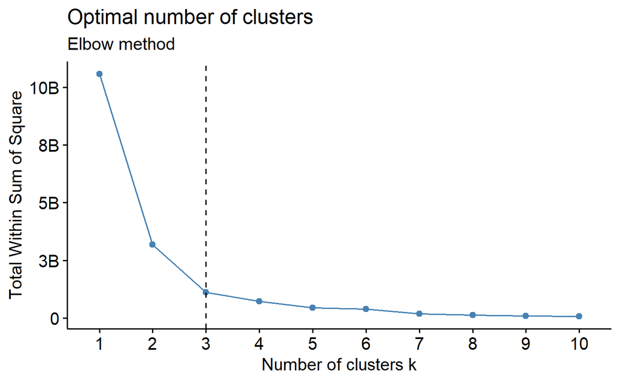

We therefore see from the graph above that the optimal number of clusters is 3. When using the k-means method, the allocation of countries according to their cluster is as follows:

**Table 6**: Cluster 1

[output not shown]

**Table 7**: Cluster 2

|  | avg_gdp | gdp_per_person | prop_men_diabetes | prop_women_diabetes | cal_prot_animal | cal_prot_plant | cal_carbs | cal_fat | total_consumption | cluster |
| --- | --- | --- | --- | --- | --- | --- | --- | --- | --- | --- |
| BGR | 37.41 | 4988 | 0.073 | 0.064 | 155 | 168 | 1606 | 846 | 2775 | 2 |
| HRV | 48.12 | 11189 | 0.071 | 0.059 | 168 | 148 | 1691 | 940 | 2946 | 2 |
| CYP | 20.15 | 18890 | 0.077 | 0.056 | 197 | 127 | 1291 | 1019 | 2633 | 2 |
| CZE | 158.48 | 15283 | 0.078 | 0.065 | 218 | 153 | 1728 | 1155 | 3254 | 2 |
| EST | 16.47 | 12283 | 0.071 | 0.064 | 212 | 167 | 1967 | 842 | 3188 | 2 |
| GRC | 246.19 | 22344 | 0.069 | 0.060 | 250 | 204 | 1744 | 1338 | 3536 | 2 |
| HUN | 110.92 | 11050 | 0.080 | 0.063 | 193 | 153 | 1560 | 1221 | 3126 | 2 |
| LVA | 21.04 | 9774 | 0.071 | 0.065 | 203 | 154 | 1687 | 1044 | 3087 | 2 |
| LTU | 30.77 | 9697 | 0.078 | 0.069 | 274 | 198 | 2055 | 858 | 3385 | 2 |
| MLT | 7.27 | 17759 | 0.088 | 0.066 | 237 | 204 | 1932 | 994 | 3367 | 2 |
| POL | 365.43 | 9586 | 0.074 | 0.066 | 204 | 197 | 1969 | 1035 | 3405 | 2 |
| PRT | 200.37 | 19077 | 0.075 | 0.052 | 275 | 177 | 1824 | 1240 | 3516 | 2 |
| ROU | 125.08 | 6062 | 0.062 | 0.059 | 200 | 220 | 2003 | 916 | 3340 | 2 |
| SVK | 70.82 | 13146 | 0.072 | 0.059 | 140 | 150 | 1610 | 952 | 2853 | 2 |
| SVN | 39.50 | 19502 | 0.066 | 0.065 | 230 | 168 | 1664 | 1067 | 3129 | 2 |
| ESP | 1176.91 | 26263 | 0.084 | 0.059 | 279 | 159 | 1481 | 1323 | 3243 | 2 |

**Table 8**: Cluster 3

[output not shown]

It is important to note that our 3rd cluster only contains 2 countries, and therefore when we analyse correlation and linear regression parameters, we will be mainly considering the overall nature of the relationships. (positive or negative link?)

To go further, we decided to represent these clusters on a map.

[interactive chart not shown]

We can see that the first cluster is located more in the North and center of Europe while the second cluster is more towards the extremities (West and East). We can ask ourselves what differentiates these eastern and western countries of Europe. For this we will look at how diabetes is distributed geographically.

[interactive chart not shown]

On the map, we can see that diabetes is mainly located in the South of Europe and precisely at the eastern and western ends. Do we get the same result for women?

[interactive chart not shown]

Women with diabetes seem to be mainly located in the eastern and south-western regions of Europe, which corresponds to the countries of cluster 2 that have a higher diabetes rate.

[interactive chart not shown]

We observe that the countries that are in cluster 2 have a lower GDP. Let’s see if we can reaffirm this claim with a cluster plot.

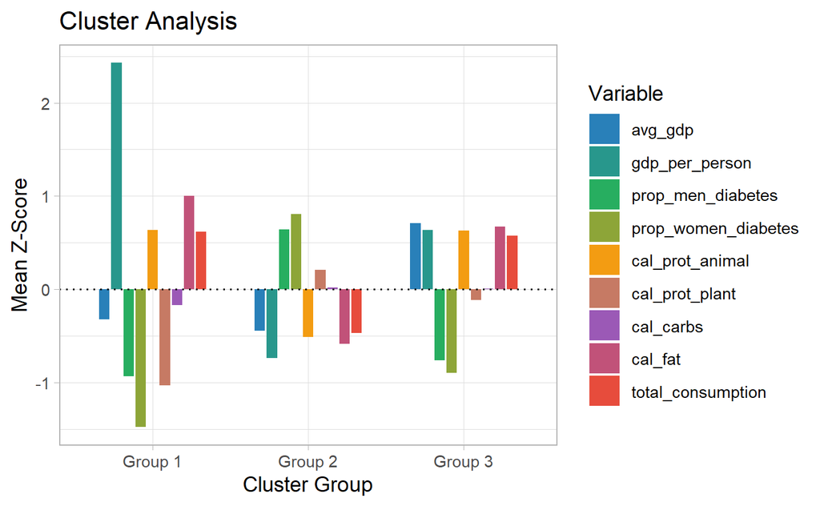

In the graph above,

- Group 1 = Cluster 3
- Group 2 = Cluster 2
- Group 3 = Cluster 1

We can therefore see that diabetes is indeed lower in clusters which contain the countries with higher GPDs. Let’s see if this relationship is significant within each cluster :

**Correlation for cluster 1**

| Between average GDP and women diabetes rate | 0.368 |
| --- | --- |
| Between average GDP and men diabetes rate | 0.297 |

|  | Average GDP vs Women diabetes rate (cluster 1) |  |  |  |
| --- | --- | --- | --- | --- |
| Predictors | Estimates | std. Error | Statistic | p |
| (Intercept) | -1949.02 | 2590.14 | -0.75 | 0.471 |
| prop women diabetes | 73395.77 | 61776.03 | 1.19 | 0.265 |
| Observations | 11 |  |  |  |
| R<sup>2</sup> / R<sup>2</sup> adjusted | 0.136 / 0.040 |  |  |  |

|  | Average GDP vs Men diabetes rate (cluster 1) |  |  |  |
| --- | --- | --- | --- | --- |
| Predictors | Estimates | std. Error | Statistic | p |
| (Intercept) | -1823.00 | 3150.00 | -0.58 | 0.577 |
| prop men diabetes | 48218.14 | 51590.68 | 0.93 | 0.374 |
| Observations | 11 |  |  |  |
| R<sup>2</sup> / R<sup>2</sup> adjusted | 0.088 / -0.013 |  |  |  |

**Correlation for cluster 2**

| Between average GDP and women diabetes rate | -0.235 |
| --- | --- |
| Between average GDP and men diabetes rate | 0.325 |

|  | Average GDP vs Women diabetes (cluster 2) |  |  |  |
| --- | --- | --- | --- | --- |
| Predictors | Estimates | std. Error | Statistic | p |
| (Intercept) | 1113.78 | 1048.47 | 1.06 | 0.306 |
| prop women diabetes | -15283.41 | 16887.89 | -0.90 | 0.381 |
| Observations | 16 |  |  |  |
| R<sup>2</sup> / R<sup>2</sup> adjusted | 0.055 / -0.012 |  |  |  |

|  | Average GDP vs Men diabetes (cluster 2) |  |  |  |
| --- | --- | --- | --- | --- |
| Predictors | Estimates | std. Error | Statistic | p |
| (Intercept) | -901.34 | 834.85 | -1.08 | 0.299 |
| prop men diabetes | 14396.62 | 11208.38 | 1.28 | 0.220 |
| Observations | 16 |  |  |  |
| R<sup>2</sup> / R<sup>2</sup> adjusted | 0.105 / 0.042 |  |  |  |

**Correlation for cluster 3**

| Between average GDP and women diabetes rate | -1 |
| --- | --- |
| Between average GDP and men diabetes rate | -1 |

|  | Average GDP vs Women diabetes (cluster 3) |  |  |  |
| --- | --- | --- | --- | --- |
| Predictors | Estimates | std. Error | Statistic | p |
| (Intercept) | 1920.92 | NaN | NaN | NaN |
| prop women diabetes | -47597.62 | NaN | NaN | NaN |
| Observations | 2 |  |  |  |
| R<sup>2</sup> / R<sup>2</sup> adjusted | 1.000 / NaN |  |  |  |

|  | Average GDP vs Men diabetes (cluster 3) |  |  |  |
| --- | --- | --- | --- | --- |
| Predictors | Estimates | std. Error | Statistic | p |
| (Intercept) | 1698.19 | NaN | NaN | NaN |
| prop men diabetes | -24247.81 | NaN | NaN | NaN |
| Observations | 2 |  |  |  |
| R<sup>2</sup> / R<sup>2</sup> adjusted | 1.000 / NaN |  |  |  |

Clustering here doesn’t necessarily help us answer the research question. We can confirm with the previous statistical test without outliers that overall, the GDP of a country and its diabetes rate are negatively correlated.

However, the clusters defined above could help us answer our other research questions.

## 4.2 Do European countries that have higher GDPs consume less calories ?

As mentioned in the first point, countries with a higher GDP tend to have a lower diabetes rate, which could potentially be explained by the consumption of fewer calories.

But is there a real correlation between these two variables ? Let’s check :

**Correlation**

| Between average GDP and total calories | 0.355 |
| --- | --- |

|  | Average GDP vs total consumption |  |  |  |
| --- | --- | --- | --- | --- |
| Predictors | Estimates | std. Error | Statistic | p |
| (Intercept) | -3017.67 | 1806.15 | -1.67 | 0.106 |
| total consumption | 1.07 | 0.55 | 1.97 | 0.059 |
| Observations | 29 |  |  |  |
| R<sup>2</sup> / R<sup>2</sup> adjusted | 0.126 / 0.093 |  |  |  |

Neither the correlation between these two variables nor the linear regression is significant. However, it would be interesting to look further. First, we can see if using the GDP per person instead of the total average makes a difference.

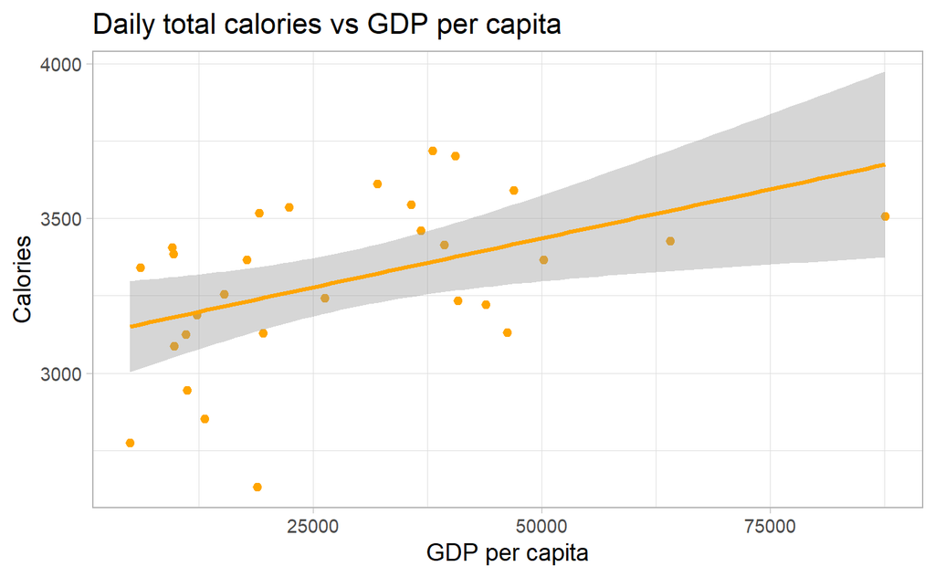

The plot looks more or less the same as the one in the EDA section without the outliers. But is the relationship with this new variable statistically significant ?

**Correlation**

| Between GDP per person and total calories | 0.458 |
| --- | --- |

|  | GDP per person vs total consumption |  |  |  |
| --- | --- | --- | --- | --- |
| Predictors | Estimates | std. Error | Statistic | p |
| (Intercept) | -80976.25 | 41007.78 | -1.97 | 0.059 |
| total consumption | 33.19 | 12.39 | 2.68 | **0.012** |
| Observations | 29 |  |  |  |
| R<sup>2</sup> / R<sup>2</sup> adjusted | 0.210 / 0.181 |  |  |  |

Next we can proceed with an analysis within clusters, with the ones defined in the first question.

**Correlation for cluster 1**

| Between GDP per person and total calories | -0.469 |
| --- | --- |

|  | GDP per person vs total consumption (cluster 1) |  |  |  |
| --- | --- | --- | --- | --- |
| Predictors | Estimates | std. Error | Statistic | p |
| (Intercept) | 84886.45 | 27655.84 | 3.07 | **0.013** |
| total consumption | -12.72 | 7.99 | -1.59 | 0.146 |
| Observations | 11 |  |  |  |
| R<sup>2</sup> / R<sup>2</sup> adjusted | 0.220 / 0.133 |  |  |  |

**Correlation for cluster 2**

| Between GDP per person and total calories | 0.224 |
| --- | --- |

|  | GDP per person vs total consumption (cluster 2) |  |  |  |
| --- | --- | --- | --- | --- |
| Predictors | Estimates | std. Error | Statistic | p |
| (Intercept) | -1941.55 | 18811.00 | -0.10 | 0.919 |
| total consumption | 5.08 | 5.91 | 0.86 | 0.404 |
| Observations | 16 |  |  |  |
| R<sup>2</sup> / R<sup>2</sup> adjusted | 0.050 / -0.018 |  |  |  |

**Correlation for cluster 3**

| Between GDP per person and total calories | 1 |
| --- | --- |

|  | GDP per person vs total consumption (cluster 3) |  |  |  |
| --- | --- | --- | --- | --- |
| Predictors | Estimates | std. Error | Statistic | p |
| (Intercept) | -939315.96 | NaN | NaN | NaN |
| total consumption | 292.84 | NaN | NaN | NaN |
| Observations | 2 |  |  |  |
| R<sup>2</sup> / R<sup>2</sup> adjusted | 1.000 / NaN |  |  |  |

The results indicate that even within the clusters, these variables are not exactly correlated and the total calories consumed per person in a country is not a significant indicator of this country’s wealth.

When we look at our cluster plot, in terms of total calorie intake it is also the 1st cluster, which contains the richest countries considering GDP per capita, that consumes the most calories. One might therefore think that calorie consumption is not the main reason why high-GDP countries have lower diabetes rates.

## 4.3 How do the macronutrients consumed differ between richer and poorer countries ?

We observed during the EDA that richer countries seemed to consume more fat on average. Now we want to see if we can confirm this relationship, and find out if there is a correlation between the average GDP of a country and the calories consumed for other macronutrients too.

Since the units of the variables “calories consumed from animal protein/plant protein/carbs/fat” are on a per capita basis, we think that including the GDP per capita in this part of the analysis could improve results. Additionally, we thought that another way of answering this research question could be to include the proportions of the calories consumed from different macronutrients on the total calories and see if it affects our analysis.

With these new metrics introduced, we will plot these relationships again.

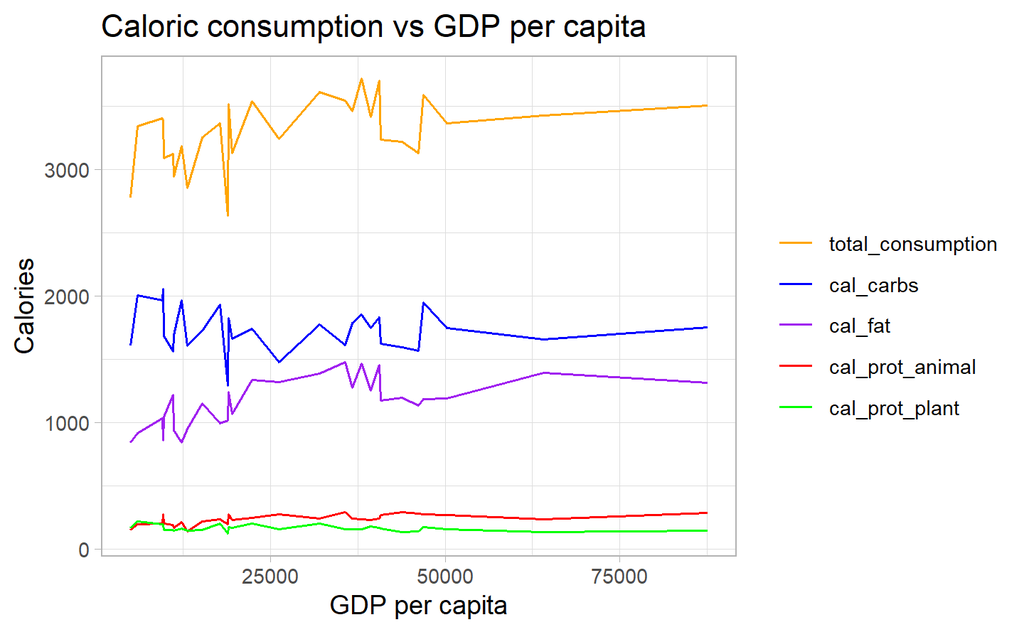

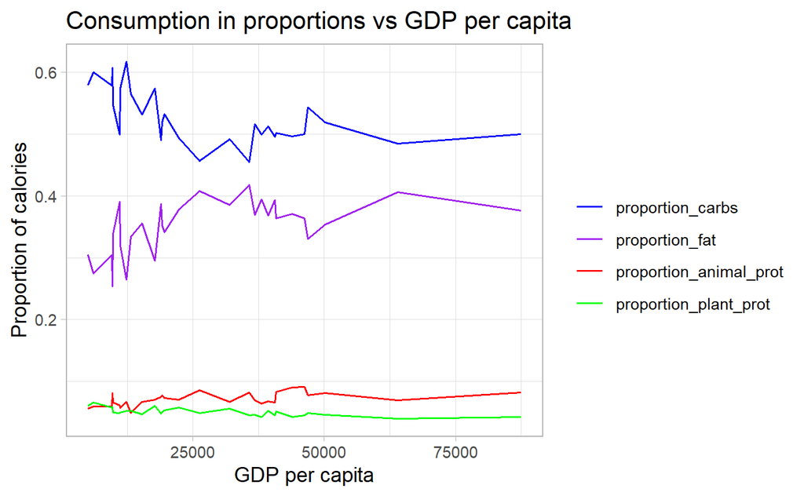

It is also important to plot the clusters again to observe differences in the proportions of calories consumed.

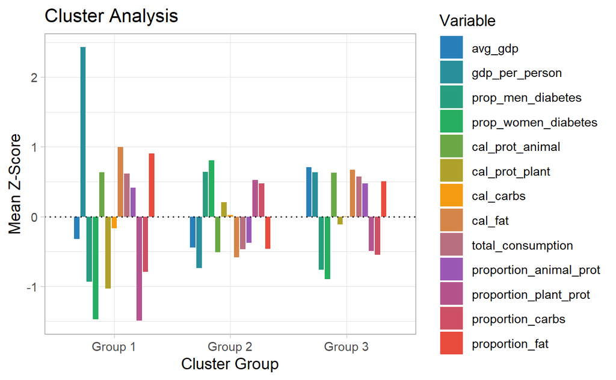

We will be referring to these graphs and this cluster plot in our analysis in the next sections.

### 4.3.1 GDP - Animal protein

Let’s start with by analysing the relationship between a country’s wealth and its consumption of animal protein. We saw at the EDA section that there didn’t seem to be a trend between these 2 variables, overall the calories consumed from animal protein is very stable regardless of the average GDP of a country. We can confirm this by checking the correlation and by trying to fit a linear regression.

**Correlation**

| Between average GDP and calories from animal protein | 0.272 |
| --- | --- |

|  | Average GDP vs calories from animal protein |  |  |  |
| --- | --- | --- | --- | --- |
| Predictors | Estimates | std. Error | Statistic | p |
| (Intercept) | -716.41 | 860.87 | -0.83 | 0.413 |
| cal prot animal | 5.28 | 3.59 | 1.47 | 0.153 |
| Observations | 29 |  |  |  |
| R<sup>2</sup> / R<sup>2</sup> adjusted | 0.074 / 0.040 |  |  |  |

Even though the correlation is positive, it is not very high. By looking at the summary of the linear regression, we can also see that the parameter is not significant. But what if we took the GDP per capita instead of the average GDP of a country ? The graph above seems to show again that the consumption of this macronutrient is very stable regardless of the GDP per capita of a country.

**Correlation**

| Between GDP per person and calories from animal protein | 0.637 |
| --- | --- |

|  | Between GDP per person and calories from animal protein |  |  |  |
| --- | --- | --- | --- | --- |
| Predictors | Estimates | std. Error | Statistic | p |
| (Intercept) | -41157.10 | 16464.75 | -2.50 | **0.019** |
| cal prot animal | 295.34 | 68.69 | 4.30 | **<0.001** |
| Observations | 29 |  |  |  |
| R<sup>2</sup> / R<sup>2</sup> adjusted | 0.406 / 0.384 |  |  |  |

This time, the correlation is higher and the variable’s estimate as a parameter is very significant ! Maybe the correlation can improve by considering proportion of calories instead of the calorie count.

**Correlation**

| Between GDP per person and proportion of calories from animal protein | 0.536 |
| --- | --- |

|  | Between GDP per person and proportion of calories from animal protein |  |  |  |
| --- | --- | --- | --- | --- |
| Predictors | Estimates | std. Error | Statistic | p |
| (Intercept) | -41451.02 | 21463.09 | -1.93 | 0.064 |
| proportion animal prot | 981450.06 | 297643.37 | 3.30 | **0.003** |
| Observations | 29 |  |  |  |
| R<sup>2</sup> / R<sup>2</sup> adjusted | 0.287 / 0.261 |  |  |  |

Here, the correlation is slightly lower than with the calorie count and the parameter’s estimate is a bit less significant but still quite solid. Now let’s see if we can find this positive relationship and better explanations within our defined clusters.

From our cluster plot above, we see that high GDP countries (clusters 1 and 3) tend to consume more calories of animal protein than low GDP countries, this is also the case for the proportions of calories consumed from animal protein. This follows what we have found so far. Are the correlations and linear regression in line with these observations ?

**Correlation for cluster 1**

| Between GDP per person and proportion of calories from animal protein | 0.566 |
| --- | --- |

|  | Between GDP per person and proportion of calories from animal protein |  |  |  |
| --- | --- | --- | --- | --- |
| Predictors | Estimates | std. Error | Statistic | p |
| (Intercept) | 17379.15 | 11526.77 | 1.51 | 0.166 |
| proportion animal prot | 308366.99 | 149728.86 | 2.06 | 0.070 |
| Observations | 11 |  |  |  |
| R<sup>2</sup> / R<sup>2</sup> adjusted | 0.320 / 0.245 |  |  |  |

**Correlation for cluster 2**

| Between GDP per person and proportion of calories from animal protein | 0.676 |
| --- | --- |

|  | Between GDP per person and proportion of calories from animal protein |  |  |  |
| --- | --- | --- | --- | --- |
| Predictors | Estimates | std. Error | Statistic | p |
| (Intercept) | -13068.03 | 8010.86 | -1.63 | 0.125 |
| proportion animal prot | 404664.90 | 117758.56 | 3.44 | **0.004** |
| Observations | 16 |  |  |  |
| R<sup>2</sup> / R<sup>2</sup> adjusted | 0.458 / 0.419 |  |  |  |

**Correlation for cluster 3**

| Between GDP per person and proportion of calories from animal protein | 1 |
| --- | --- |

|  | Between GDP per person and proportion of calories from animal protein |  |  |  |
| --- | --- | --- | --- | --- |
| Predictors | Estimates | std. Error | Statistic | p |
| (Intercept) | -61499.76 | NaN | NaN | NaN |
| proportion animal prot | 1812514.02 | NaN | NaN | NaN |
| Observations | 2 |  |  |  |
| R<sup>2</sup> / R<sup>2</sup> adjusted | 1.000 / NaN |  |  |  |

For each cluster, the correlation is positive and relatively strong, but only the estimate of the parameter for cluster 2 is significant.

In general, we could conclude that there is a positive link between the wealth of a country and its animal protein consumption.

### 4.3.2 GDP - Plant protein

Now let’s move on to the analysis of the relationship between a country’s wealth and it’s consumption of plant protein. We saw at the EDA section, again, that there didn’t seem to be a trend between these 2 variables. The calories consumed from plant protein is very stable as we can see from the horizontal line, regardless of the average GDP of a country. To confirm this, we will check the correlation.

**Correlation**

| Between average GDP and calories from plant protein | 0.043 |
| --- | --- |

|  | Between average GDP and calories from plant protein |  |  |  |
| --- | --- | --- | --- | --- |
| Predictors | Estimates | std. Error | Statistic | p |
| (Intercept) | 276.48 | 1135.65 | 0.24 | 0.809 |
| cal prot plant | 1.52 | 6.75 | 0.23 | 0.823 |
| Observations | 29 |  |  |  |
| R<sup>2</sup> / R<sup>2</sup> adjusted | 0.002 / -0.035 |  |  |  |

As we can see, the correlation is very low and when we try to fit a linear model over these 2 variables, the parameter estimation is not significant at all. Let’s see if taking the GDP per capita makes a difference. In the graph above, the consumption of this macronutrient is very stable too.

**Correlation**

| Between GDP per person and calories from plant protein | -0.357 |
| --- | --- |

|  | Between GDP per person and calories from plant protein |  |  |  |
| --- | --- | --- | --- | --- |
| Predictors | Estimates | std. Error | Statistic | p |
| (Intercept) | 78466.08 | 25364.62 | 3.09 | **0.005** |
| cal prot plant | -299.07 | 150.66 | -1.99 | 0.057 |
| Observations | 29 |  |  |  |
| R<sup>2</sup> / R<sup>2</sup> adjusted | 0.127 / 0.095 |  |  |  |

The correlation improves when we consider the GDP per capita instead of the average. We also see that the relationship between the 2 variables is rather negative. However the parameter estimation is still not significant enough, even though it improved. Can we find a better explanation by using the proportion of calories rather than the calorie count of the plant protein consumed ?

**Correlation**

| Between GDP per person and proportion of calories from plant protein | -0.683 |
| --- | --- |

|  | Between GDP per person and proportion of calories from plant protein |  |  |  |
| --- | --- | --- | --- | --- |
| Predictors | Estimates | std. Error | Statistic | p |
| (Intercept) | 135049.20 | 22065.03 | 6.12 | **<0.001** |
| proportion plant prot | -2103072.30 | 432611.97 | -4.86 | **<0.001** |
| Observations | 29 |  |  |  |
| R<sup>2</sup> / R<sup>2</sup> adjusted | 0.467 / 0.447 |  |  |  |

The correlation improved immensely ! Now we can confirm that the relationship is rather negative, even though the correlation is rather moderate than strong. But now our parameter estimation is as significant as possible. How does this translate to our clusters ?

The cluster plot above indicates that in countries with higher GDPs like in cluster 1 and 3, the proportions of calories consumed from plant protein are lower than in countries with lower GDPs. Let’s see if we can confirm these observations and see if these relationships are strong enough within each cluster.

**Correlation for cluster 1**

| Between GDP per person and proportion of calories from plant protein | -0.351 |
| --- | --- |

|  | Between GDP per person and proportion of calories from plant protein |  |  |  |
| --- | --- | --- | --- | --- |
| Predictors | Estimates | std. Error | Statistic | p |
| (Intercept) | 61779.35 | 18585.68 | 3.32 | **0.009** |
| proportion plant prot | -438723.62 | 389754.96 | -1.13 | 0.289 |
| Observations | 11 |  |  |  |
| R<sup>2</sup> / R<sup>2</sup> adjusted | 0.123 / 0.026 |  |  |  |

**Correlation for cluster 2**

| Between GDP per person and proportion of calories from plant protein | -0.417 |
| --- | --- |

|  | Between GDP per person and proportion of calories from plant protein |  |  |  |
| --- | --- | --- | --- | --- |
| Predictors | Estimates | std. Error | Statistic | p |
| (Intercept) | 38383.00 | 14155.73 | 2.71 | **0.017** |
| proportion plant prot | -448628.20 | 261104.64 | -1.72 | 0.108 |
| Observations | 16 |  |  |  |
| R<sup>2</sup> / R<sup>2</sup> adjusted | 0.174 / 0.115 |  |  |  |

**Correlation for cluster 3**

| Between GDP per person and proportion of calories from plant protein | 1 |
| --- | --- |

|  | Between GDP per person and proportion of calories from plant protein |  |  |  |
| --- | --- | --- | --- | --- |
| Predictors | Estimates | std. Error | Statistic | p |
| (Intercept) | -398204.08 | NaN | NaN | NaN |
| proportion plant prot | 11498699.32 | NaN | NaN | NaN |
| Observations | 2 |  |  |  |
| R<sup>2</sup> / R<sup>2</sup> adjusted | 1.000 / NaN |  |  |  |

We see that the correlations within clusters is weaker. And actually, even in countries with lower GDPs that belong to cluster 2, the relationship is rather negative. This indicates us that visual interpretation is not enough for analysis. We can maybe say that less wealthy countries that are more developed (than those in the same cluster as them) may consume more plant protein than more wealthy countries but they still consume less of this macronutrient than their cluster mates.

So overall, we could conclude that there is a negative relationship between the wealth of a country and its plant protein consumption.

### 4.3.3 GDP - Carbohydrates

Next, we will be evaluating the relationship of a country’s GDP and its carbohydrate consumption. In the EDA graph, there isn’t really trend in general between these 2 variables. The calories consumed from carbs is more or less stable for countries with an average GDP of around 500 billion dollars and more. Let’s check the correlation.

**Correlation**

| Between average GDP and calories from carbs | -0.083 |
| --- | --- |

|  | Between average GDP and calories from carbs |  |  |  |
| --- | --- | --- | --- | --- |
| Predictors | Estimates | std. Error | Statistic | p |
| (Intercept) | 1212.64 | 1588.16 | 0.76 | 0.452 |
| cal carbs | -0.39 | 0.91 | -0.43 | 0.669 |
| Observations | 29 |  |  |  |
| R<sup>2</sup> / R<sup>2</sup> adjusted | 0.007 / -0.030 |  |  |  |

The correlation is negative and very low. This could maybe be explained by the fact that variance is very high at the left part of the graph where the average GDP is lower, up until 500 billion dollars. The parameter estimation is not significant either, this regression is not appropriate to explain this relationship.

But what if we compared the 2 metrics at the same unit level like in the previous 2 sections ? Our graph above indicates that there may be a slight decrease of the caloric intake of carbs per capita the more a country’s GDP per capita is higher. Let’s see if this is true.

**Correlation**

| Between GDP per person and calories from carbs | -0.105 |
| --- | --- |

|  | Between GDP per person and calories from carbs |  |  |  |
| --- | --- | --- | --- | --- |
| Predictors | Estimates | std. Error | Statistic | p |
| (Intercept) | 49289.50 | 37855.69 | 1.30 | 0.204 |
| cal carbs | -11.94 | 21.72 | -0.55 | 0.587 |
| Observations | 29 |  |  |  |
| R<sup>2</sup> / R<sup>2</sup> adjusted | 0.011 / -0.026 |  |  |  |

Indeed, the correlation is higher now but it is still not strong enough. Our parameter is once again not significant to explain this new dependent variable either. But what if we changed our independent variable ? Because we see in the second graph above that this negative slope is even more accentuated when we take into account the proportion of the carbs consumed instead of their calorie count.

**Correlation**

| Between GDP per person and proportion of calories from carbs | -0.575 |
| --- | --- |

|  | Between GDP per person and proportion of calories from carbs |  |  |  |
| --- | --- | --- | --- | --- |
| Predictors | Estimates | std. Error | Statistic | p |
| (Intercept) | 163176.52 | 36974.37 | 4.41 | **<0.001** |
| proportion carbs | -255576.19 | 69975.38 | -3.65 | **0.001** |
| Observations | 29 |  |  |  |
| R<sup>2</sup> / R<sup>2</sup> adjusted | 0.331 / 0.306 |  |  |  |

The correlation between these 2 variables is way more important, we can even say that their correlation is moderately strong. And the parameter estimation when we fit a linear model is quite significant. Let’s observe these relationships now within each cluster. According to our cluster plot, countries of cluster 1 and 3 (high GDP) consume a smaller proportion of carbs then those of cluster 2 (low GDP).

**Correlation for cluster 1**

| Between GDP per person and proportion of calories from carbs | 0.553 |
| --- | --- |

|  | Between GDP per person and proportion of calories from carbs |  |  |  |
| --- | --- | --- | --- | --- |
| Predictors | Estimates | std. Error | Statistic | p |
| (Intercept) | -28376.28 | 34846.14 | -0.81 | 0.436 |
| proportion carbs | 137918.44 | 69276.82 | 1.99 | 0.078 |
| Observations | 11 |  |  |  |
| R<sup>2</sup> / R<sup>2</sup> adjusted | 0.306 / 0.229 |  |  |  |

**Correlation for cluster 2**

| Between GDP per person and proportion of calories from carbs | -0.751 |
| --- | --- |

|  | Between GDP per person and proportion of calories from carbs |  |  |  |
| --- | --- | --- | --- | --- |
| Predictors | Estimates | std. Error | Statistic | p |
| (Intercept) | 66623.14 | 12383.47 | 5.38 | **<0.001** |
| proportion carbs | -95782.01 | 22540.38 | -4.25 | **0.001** |
| Observations | 16 |  |  |  |
| R<sup>2</sup> / R<sup>2</sup> adjusted | 0.563 / 0.532 |  |  |  |

**Correlation for cluster 3**

| Between GDP per person and proportion of calories from carbs | 1 |
| --- | --- |

|  | Between gdp per person and proportion of calories from carbs |  |  |  |
| --- | --- | --- | --- | --- |
| Predictors | Estimates | std. Error | Statistic | p |
| (Intercept) | -678064.39 | NaN | NaN | NaN |
| proportion carbs | 1532052.98 | NaN | NaN | NaN |
| Observations | 2 |  |  |  |
| R<sup>2</sup> / R<sup>2</sup> adjusted | 1.000 / NaN |  |  |  |

Surprisingly, with these correlations we see that the previous logic is inversed within clusters. For richer countries like those in cluster 1 and 3 the link between GDP and carbs consumption is positive within their respective clusters, and for less rich countries like in those in cluster 2, it is negative. The estimate for the model parameter for cluster 2 is even very significant.

Though in general, we could conclude that the link between the wealth of a country and its carb consumption is negative.

### 4.3.4 GDP - Fats

For the last part of our 3rd research question, let’s analyse the relationship of a country’s GDP and its fat consumption. Once again when we take a look at the graph at the EDA section, at the left side of the graph, there seems to be a slight increase. But the calories consumed from fat is more or less stable for countries with an average GDP of around 500 billion dollars and more, just like for the carbs. What does the correlation coefficient tell us ?

**Correlation**

| Between average GDP and calories from fat | 0.503 |
| --- | --- |

|  | Between average GDP and calories from fat |  |  |  |
| --- | --- | --- | --- | --- |
| Predictors | Estimates | std. Error | Statistic | p |
| (Intercept) | -1941.46 | 827.39 | -2.35 | **0.027** |
| cal fat | 2.13 | 0.70 | 3.03 | **0.005** |
| Observations | 29 |  |  |  |
| R<sup>2</sup> / R<sup>2</sup> adjusted | 0.253 / 0.226 |  |  |  |

From the get-go, the correlation is moderately high and positive. The estimation of the model parameter is also quite significant. Does taking the GDP per capita change our results ? In the first graph above, the fat consumption seems to very slightly increase when a country’s GDP is higher. Let’s check.

**Correlation**

| Between GDP per person and calories from fat | 0.636 |
| --- | --- |

|  | Between GDP per person and calories from fat |  |  |  |
| --- | --- | --- | --- | --- |
| Predictors | Estimates | std. Error | Statistic | p |
| (Intercept) | -46079.39 | 17640.70 | -2.61 | **0.015** |
| cal fat | 64.23 | 14.98 | 4.29 | **<0.001** |
| Observations | 29 |  |  |  |
| R<sup>2</sup> / R<sup>2</sup> adjusted | 0.405 / 0.383 |  |  |  |

Our hypothesis was right. Not only did the correlation between the 2 variables increase, but the significance of the parameter estimation also improved. And how does switching the calorie count with the proportion of fat consumed per capita affect the correlation with the GDP per capita ? On the second graph above, we see that, just like for carbs, the positive slope becomes a bit more accentuated.

**Correlation**

| Between GDP per person and proportion of calories from fat | 0.544 |
| --- | --- |

|  | Between GDP per person and proportion of calories from fat |  |  |  |
| --- | --- | --- | --- | --- |
| Predictors | Estimates | std. Error | Statistic | p |
| (Intercept) | -56316.18 | 25410.86 | -2.22 | **0.035** |
| proportion fat | 241607.12 | 71783.98 | 3.37 | **0.002** |
| Observations | 29 |  |  |  |
| R<sup>2</sup> / R<sup>2</sup> adjusted | 0.296 / 0.269 |  |  |  |

This time, the correlation and the significance of the parameter goes down a little bit, even though not dramatically. Let’s see once more what these relationships are like within each cluster. By looking at the cluster plot, we can hypothesize that wealthier countries of cluster 1 and 3 consume a bigger proportion of fat then those of cluster 2 that are less wealthy.

**Correlation for cluster 1**

| Between GDP per person and proportion of calories from fat | -0.695 |
| --- | --- |

|  | Between GDP per person and proportion of calories from fat |  |  |  |
| --- | --- | --- | --- | --- |
| Predictors | Estimates | std. Error | Statistic | p |
| (Intercept) | 101563.63 | 20955.14 | 4.85 | **0.001** |
| proportion fat | -162307.53 | 56002.68 | -2.90 | **0.018** |
| Observations | 11 |  |  |  |
| R<sup>2</sup> / R<sup>2</sup> adjusted | 0.483 / 0.425 |  |  |  |

**Correlation for cluster 2**

| Between GDP per person and proportion of calories from fat | 0.659 |
| --- | --- |

|  | Between GDP per person and proportion of calories from fat |  |  |  |
| --- | --- | --- | --- | --- |
| Predictors | Estimates | std. Error | Statistic | p |
| (Intercept) | -13798.71 | 8617.08 | -1.60 | 0.132 |
| proportion fat | 84479.61 | 25779.67 | 3.28 | **0.006** |
| Observations | 16 |  |  |  |
| R<sup>2</sup> / R<sup>2</sup> adjusted | 0.434 / 0.394 |  |  |  |

**Correlation for cluster 3**

| Between GDP per person and proportion of calories from fat | -1 |
| --- | --- |

|  | Between GDP per person and proportion of calories from fat |  |  |  |
| --- | --- | --- | --- | --- |
| Predictors | Estimates | std. Error | Statistic | p |
| (Intercept) | 378543.88 | NaN | NaN | NaN |
| proportion fat | -774350.31 | NaN | NaN | NaN |
| Observations | 2 |  |  |  |
| R<sup>2</sup> / R<sup>2</sup> adjusted | 1.000 / NaN |  |  |  |

Just like for carbs, surprisingly, we see again that the previous logic is inversed within clusters by looking at these correlations. For high GDP countries like those in cluster 1 and 3 the link between GDP and fat consumption is negative within their respective clusters, and for low GDP countries like in those in cluster 2, it is positive. The estimate for the model parameter for cluster 2 is again quite significant. This suggests that among rich countries, the countries that are the most rich tend to consume less fat, and vice versa.

Therefore, we could say by looking at the overall results that there is a positive link between the wealth of a country and its fat consumption.

## 4.4 How do these differences in macronutrients relate to the diabetes prevalence in these countries ? What is the typical diet that can be observed in richer states that relates to lower diabetes prevalence ?

What we observed in the EDA seemed to not make sense to us as we were expecting a positive relationship between the total calories/calories consumed from fat and diabetes prevalence in a country. Let’s see now concretely if there is any correlation between the calories consumed from different macronutrients and the diabetes rate.

**Correlation between diabetes rate per sex and calories from**

|  | Animal protein | Plant protein | Carbs | Fat |
| --- | --- | --- | --- | --- |
| Men | -0.246 | 0.227 | -0.032 | -0.404 |
| Women | -0.515 | 0.387 | 0.155 | -0.697 |

But we also saw in the previous question that taking into account the proportions rather than the calorie count for the macronutrients gave us better results. Let’s see if the correlation with diabetes prevalence improves too.

**Correlation between diabetes rate per sex and proportion of calories from**

|  | Animal protein | Plant protein | Carbs | Fat |
| --- | --- | --- | --- | --- |
| Men | -0.141 | 0.452 | 0.272 | -0.303 |
| Women | -0.399 | 0.706 | 0.616 | -0.621 |

It does ! So to answer this question, we will rather work with the variables related to the proportions of the different macronutrients consumed than the exact calories consumed.

We will now look in more detail at the relationship of each macronutrient with diabetes prevalence, starting with animal protein.

### 4.4.1 Diabetes - Animal protein

In the EDA, we observe a decreasing trend for the animal protein related to diabetes. The graph below with the proportions give us more or less the same result.

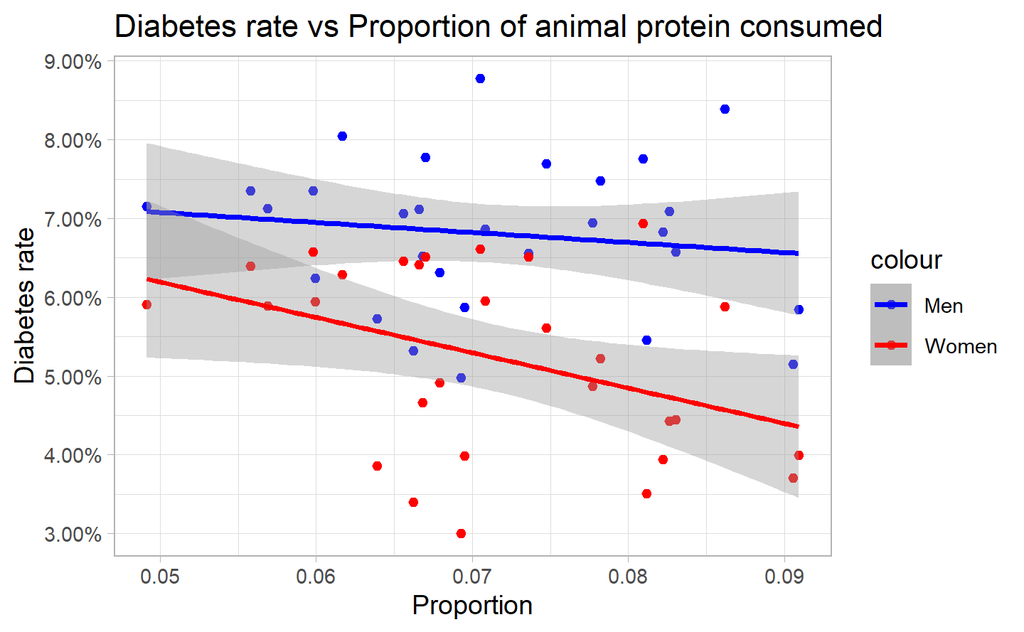

At the beginning of this question we saw that the correlation between these 2 variables is negative, but not very strong. This can be confirmed with the results of the linear regression below too.

|  | Diabetes rate for men vs proportion of calories from animal protein |  |  |  |
| --- | --- | --- | --- | --- |
| Predictors | Estimates | std. Error | Statistic | p |
| (Intercept) | 0.08 | 0.01 | 6.19 | **<0.001** |
| proportion animal prot | -0.13 | 0.17 | -0.74 | 0.466 |
| Observations | 29 |  |  |  |
| R<sup>2</sup> / R<sup>2</sup> adjusted | 0.020 / -0.016 |  |  |  |

|  | Diabetes rate for women vs proportion of calories from animal protein |  |  |  |
| --- | --- | --- | --- | --- |
| Predictors | Estimates | std. Error | Statistic | p |
| (Intercept) | 0.08 | 0.01 | 5.89 | **<0.001** |
| proportion animal prot | -0.45 | 0.20 | -2.26 | **0.032** |
| Observations | 29 |  |  |  |
| R<sup>2</sup> / R<sup>2</sup> adjusted | 0.159 / 0.128 |  |  |  |

**Correlation for cluster 1**

| Between men diabetes rate and proportion of calories from animal protein | -0.023 |
| --- | --- |
| Between women diabetes rate and proportion of calories from animal protein | -0.114 |

|  | Diabetes rate for men vs proportion of calories from animal protein |  |  |  |
| --- | --- | --- | --- | --- |
| Predictors | Estimates | std. Error | Statistic | p |
| (Intercept) | 0.06 | 0.02 | 3.66 | **0.005** |
| proportion animal prot | -0.02 | 0.22 | -0.07 | 0.947 |
| Observations | 11 |  |  |  |
| R<sup>2</sup> / R<sup>2</sup> adjusted | 0.001 / -0.111 |  |  |  |

|  | Diabetes rate for women vs proportion of calories from animal protein |  |  |  |
| --- | --- | --- | --- | --- |
| Predictors | Estimates | std. Error | Statistic | p |
| (Intercept) | 0.05 | 0.01 | 3.39 | **0.008** |
| proportion animal prot | -0.06 | 0.18 | -0.35 | 0.738 |
| Observations | 11 |  |  |  |
| R<sup>2</sup> / R<sup>2</sup> adjusted | 0.013 / -0.097 |  |  |  |

**Correlation for cluster 2**

| Between men diabetes rate and proportion of calories from animal protein | 0.386 |
| --- | --- |
| Between women diabetes rate and proportion of calories from animal protein | -0.067 |

|  | Diabetes rate for men vs proportion of calories from animal protein |  |  |  |
| --- | --- | --- | --- | --- |
| Predictors | Estimates | std. Error | Statistic | p |
| (Intercept) | 0.06 | 0.01 | 5.27 | **<0.001** |
| proportion animal prot | 0.25 | 0.16 | 1.57 | 0.140 |
| Observations | 16 |  |  |  |
| R<sup>2</sup> / R<sup>2</sup> adjusted | 0.149 / 0.088 |  |  |  |

|  | Diabetes rate for women vs proportion of calories from animal protein |  |  |  |
| --- | --- | --- | --- | --- |
| Predictors | Estimates | std. Error | Statistic | p |
| (Intercept) | 0.06 | 0.01 | 7.97 | **<0.001** |
| proportion animal prot | -0.03 | 0.12 | -0.25 | 0.804 |
| Observations | 16 |  |  |  |
| R<sup>2</sup> / R<sup>2</sup> adjusted | 0.005 / -0.067 |  |  |  |

**Correlation for cluster 3**

| Between men diabetes rate and proportion of calories from animal protein | 1 |
| --- | --- |
| Between women diabetes rate and proportion of calories from animal protein | 1 |

|  | Diabetes rate for men vs proportion of calories from animal protein |  |  |  |
| --- | --- | --- | --- | --- |
| Predictors | Estimates | std. Error | Statistic | p |
| (Intercept) | -0.05 | NaN | NaN | NaN |
| proportion animal prot | 1.42 | NaN | NaN | NaN |
| Observations | 2 |  |  |  |
| R<sup>2</sup> / R<sup>2</sup> adjusted | 1.000 / NaN |  |  |  |

|  | Diabetes rate for women vs proportion of calories from animal protein |  |  |  |
| --- | --- | --- | --- | --- |
| Predictors | Estimates | std. Error | Statistic | p |
| (Intercept) | -0.02 | NaN | NaN | NaN |
| proportion animal prot | 0.72 | NaN | NaN | NaN |
| Observations | 2 |  |  |  |
| R<sup>2</sup> / R<sup>2</sup> adjusted | 1.000 / NaN |  |  |  |

### 4.4.2 Diabetes - Plant protein

We saw at the EDA section, that there seemed to be a trend between these 2 variables. The calories consumed from plant protein seemed to increase the diabetes prevalence. As we can see in the graph below, it seems that with proportions, this slope is even more accentuated.

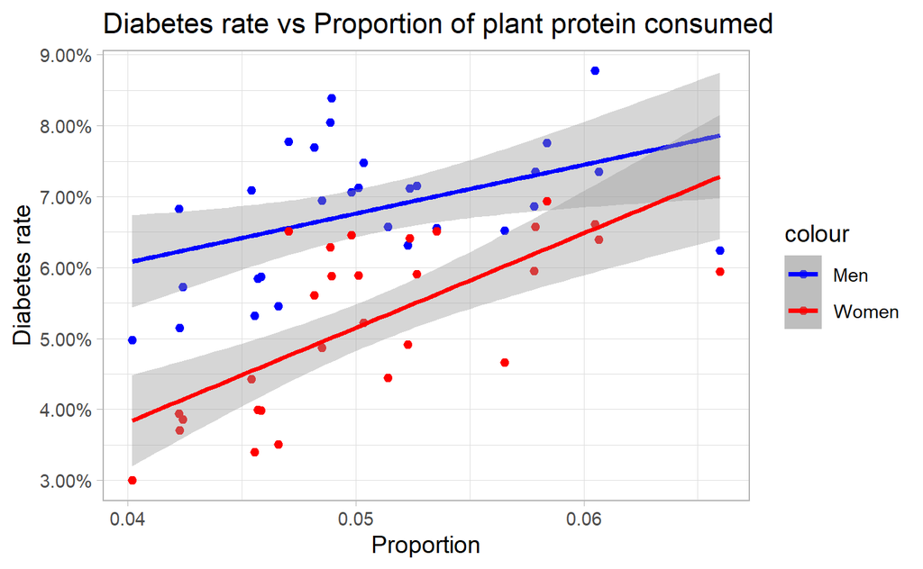

We can check if this relationship is significant with a linear regression.

|  | Diabetes rate for men vs proportion of calories from plant protein |  |  |  |
| --- | --- | --- | --- | --- |
| Predictors | Estimates | std. Error | Statistic | p |
| (Intercept) | 0.03 | 0.01 | 2.49 | **0.019** |
| proportion plant prot | 0.69 | 0.26 | 2.63 | **0.014** |
| Observations | 29 |  |  |  |
| R<sup>2</sup> / R<sup>2</sup> adjusted | 0.204 / 0.175 |  |  |  |

|  | Diabetes rate for women vs proportion of calories from plant protein |  |  |  |
| --- | --- | --- | --- | --- |
| Predictors | Estimates | std. Error | Statistic | p |
| (Intercept) | -0.02 | 0.01 | -1.15 | 0.260 |
| proportion plant prot | 1.33 | 0.26 | 5.17 | **<0.001** |
| Observations | 29 |  |  |  |
| R<sup>2</sup> / R<sup>2</sup> adjusted | 0.498 / 0.479 |  |  |  |

The parameter is very significant when trying to explain the diabetes rate in women. With correlations at 0.452 and 0.706 respectively, these relationships are also moderately strong. Is it also the case for the clusters ?

**Correlation for cluster 1**

| Between men diabetes rate and proportion of calories from plant protein | 0.535 |
| --- | --- |
| Between women diabetes rate and proportion of calories from plant protein | 0.690 |

|  | Diabetes rate for men vs proportion of calories from plant protein |  |  |  |
| --- | --- | --- | --- | --- |
| Predictors | Estimates | std. Error | Statistic | p |
| (Intercept) | 0.02 | 0.02 | 1.10 | 0.299 |
| proportion plant prot | 0.81 | 0.42 | 1.90 | 0.090 |
| Observations | 11 |  |  |  |
| R<sup>2</sup> / R<sup>2</sup> adjusted | 0.287 / 0.207 |  |  |  |

|  | Diabetes rate for women vs proportion of calories from plant protein |  |  |  |
| --- | --- | --- | --- | --- |
| Predictors | Estimates | std. Error | Statistic | p |
| (Intercept) | 0.00 | 0.01 | 0.10 | 0.923 |
| proportion plant prot | 0.85 | 0.30 | 2.86 | **0.019** |
| Observations | 11 |  |  |  |
| R<sup>2</sup> / R<sup>2</sup> adjusted | 0.476 / 0.418 |  |  |  |

**Correlation for cluster 2**

| Between men diabetes rate and proportion of calories from plant protein | -0.281 |
| --- | --- |
| Between women diabetes rate and proportion of calories from plant protein | 0.292 |

|  | Diabetes rate for men vs proportion of calories from plant protein |  |  |  |
| --- | --- | --- | --- | --- |
| Predictors | Estimates | std. Error | Statistic | p |
| (Intercept) | 0.09 | 0.02 | 5.67 | **<0.001** |
| proportion plant prot | -0.33 | 0.30 | -1.10 | 0.292 |
| Observations | 16 |  |  |  |
| R<sup>2</sup> / R<sup>2</sup> adjusted | 0.079 / 0.013 |  |  |  |

|  | Diabetes rate for women vs proportion of calories from plant protein |  |  |  |
| --- | --- | --- | --- | --- |
| Predictors | Estimates | std. Error | Statistic | p |
| (Intercept) | 0.05 | 0.01 | 4.48 | **0.001** |
| proportion plant prot | 0.23 | 0.20 | 1.14 | 0.272 |
| Observations | 16 |  |  |  |
| R<sup>2</sup> / R<sup>2</sup> adjusted | 0.085 / 0.020 |  |  |  |

**Correlation for cluster 3**

| Between men diabetes rate and proportion of calories from plant protein | 1 |
| --- | --- |
| Between women diabetes rate and proportion of calories from plant protein | 1 |

|  | Diabetes rate for men vs proportion of calories from plant protein |  |  |  |
| --- | --- | --- | --- | --- |
| Predictors | Estimates | std. Error | Statistic | p |
| (Intercept) | -0.31 | NaN | NaN | NaN |
| proportion plant prot | 9.02 | NaN | NaN | NaN |
| Observations | 2 |  |  |  |
| R<sup>2</sup> / R<sup>2</sup> adjusted | 1.000 / NaN |  |  |  |

|  | Diabetes rate for women vs proportion of calories from plant protein |  |  |  |
| --- | --- | --- | --- | --- |
| Predictors | Estimates | std. Error | Statistic | p |
| (Intercept) | -0.15 | NaN | NaN | NaN |
| proportion plant prot | 4.60 | NaN | NaN | NaN |
| Observations | 2 |  |  |  |
| R<sup>2</sup> / R<sup>2</sup> adjusted | 1.000 / NaN |  |  |  |

For all of our clusters, according to the cluster graphs, we were expecting to see a positive relationship and our results mostly corresponded to those expectations. The correlations are quite strong for men and even higher for women in high GDP countries.

However in the second cluster, there is a negative correlation between the proportion of plant protein consumed and the diabetes prevalence in men, though not very strong.

### 4.4.3 Diabetes - Carbohydrates

In the EDA, it seems that carbohydrates have a rather flat trend compared to diabetes. Our graph with proportions below however, shows us a positive slope.

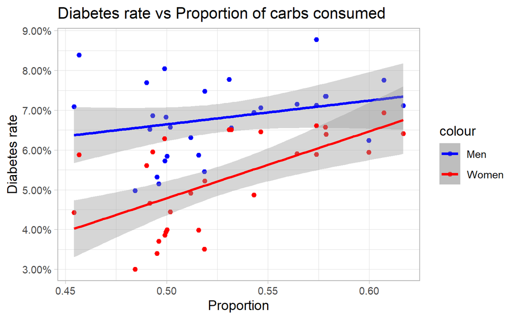

Indeed, the correlations between the proportion of carbs consumed and diabetes prevalence in men and women were positive, at 0.272 and 0.616 respectively. Let’s see the results when we try to fit a linear model.

|  | Diabetes rate for men vs proportion of calories from carbs |  |  |  |
| --- | --- | --- | --- | --- |
| Predictors | Estimates | std. Error | Statistic | p |
| (Intercept) | 0.04 | 0.02 | 1.70 | 0.101 |
| proportion carbs | 0.06 | 0.04 | 1.47 | 0.154 |
| Observations | 29 |  |  |  |
| R<sup>2</sup> / R<sup>2</sup> adjusted | 0.074 / 0.039 |  |  |  |

|  | Diabetes rate for women vs proportion of calories from carbs |  |  |  |
| --- | --- | --- | --- | --- |
| Predictors | Estimates | std. Error | Statistic | p |
| (Intercept) | -0.04 | 0.02 | -1.65 | 0.110 |
| proportion carbs | 0.17 | 0.04 | 4.06 | **<0.001** |
| Observations | 29 |  |  |  |
| R<sup>2</sup> / R<sup>2</sup> adjusted | 0.380 / 0.357 |  |  |  |

We see that the linear regression for women is very significant, so increasing carbohydrates in a women’s diet would increase their diabetes rate. What do our clusters indicate ?

**Correlation for cluster 1**

| Between men diabetes rate and proportion of calories from carbs | -0.114 |
| --- | --- |
| Between women diabetes rate and proportion of calories from carbs | 0.125 |

|  | Diabetes rate for men vs proportion of calories from carbs |  |  |  |
| --- | --- | --- | --- | --- |
| Predictors | Estimates | std. Error | Statistic | p |
| (Intercept) | 0.08 | 0.05 | 1.55 | 0.155 |
| proportion carbs | -0.03 | 0.10 | -0.34 | 0.738 |
| Observations | 11 |  |  |  |
| R<sup>2</sup> / R<sup>2</sup> adjusted | 0.013 / -0.097 |  |  |  |

|  | Diabetes rate for women vs proportion of calories from carbs |  |  |  |
| --- | --- | --- | --- | --- |
| Predictors | Estimates | std. Error | Statistic | p |
| (Intercept) | 0.03 | 0.04 | 0.64 | 0.535 |
| proportion carbs | 0.03 | 0.08 | 0.38 | 0.715 |
| Observations | 11 |  |  |  |
| R<sup>2</sup> / R<sup>2</sup> adjusted | 0.016 / -0.094 |  |  |  |

**Correlation for cluster 2**

| Between men diabetes rate and proportion of calories from carbs | -0.309 |
| --- | --- |
| Between women diabetes rate and proportion of calories from carbs | 0.486 |

|  | Diabetes rate for men vs proportion of calories from carbs |  |  |  |
| --- | --- | --- | --- | --- |
| Predictors | Estimates | std. Error | Statistic | p |
| (Intercept) | 0.10 | 0.02 | 5.05 | **<0.001** |
| proportion carbs | -0.04 | 0.04 | -1.21 | 0.245 |
| Observations | 16 |  |  |  |
| R<sup>2</sup> / R<sup>2</sup> adjusted | 0.095 / 0.031 |  |  |  |

|  | Diabetes rate for women vs proportion of calories from carbs |  |  |  |
| --- | --- | --- | --- | --- |
| Predictors | Estimates | std. Error | Statistic | p |
| (Intercept) | 0.04 | 0.01 | 3.04 | **0.009** |
| proportion carbs | 0.05 | 0.02 | 2.08 | 0.057 |
| Observations | 16 |  |  |  |
| R<sup>2</sup> / R<sup>2</sup> adjusted | 0.236 / 0.181 |  |  |  |

**Correlation for cluster 3**

| Between men diabetes rate and proportion of calories from carbs | 1 |
| --- | --- |
| Between women diabetes rate and proportion of calories from carbs | 1 |

|  | Diabetes rate for men vs proportion of calories from carbs |  |  |  |
| --- | --- | --- | --- | --- |
| Predictors | Estimates | std. Error | Statistic | p |
| (Intercept) | -0.53 | NaN | NaN | NaN |
| proportion carbs | 1.20 | NaN | NaN | NaN |
| Observations | 2 |  |  |  |
| R<sup>2</sup> / R<sup>2</sup> adjusted | 1.000 / NaN |  |  |  |

|  | Diabetes rate for women vs proportion of calories from carbs |  |  |  |
| --- | --- | --- | --- | --- |
| Predictors | Estimates | std. Error | Statistic | p |
| (Intercept) | -0.27 | NaN | NaN | NaN |
| proportion carbs | 0.61 | NaN | NaN | NaN |
| Observations | 2 |  |  |  |
| R<sup>2</sup> / R<sup>2</sup> adjusted | 1.000 / NaN |  |  |  |

For all of our clusters, we generally have positive correlations. This is what was expected by observing the cluster plot. Moreover, for the cluster 1 and 2 the correlations are negative in regards to diabetes prevalence in men. However these correlations are not strong at all, and as for our parameter estimations for the linear models we tried to fit over these variables, they are not significant.

Bur the positive trend between the consumption of carbs and diabetes prevalence is what makes the most sense to us so far, as foods that contain carbs like fast food etc tend to be bad for diabetes.

### 4.4.4 Diabetes - Fats

In the EDA part, the fats have a rather downward trend. Below, we have more or less the same graph with the proportions.

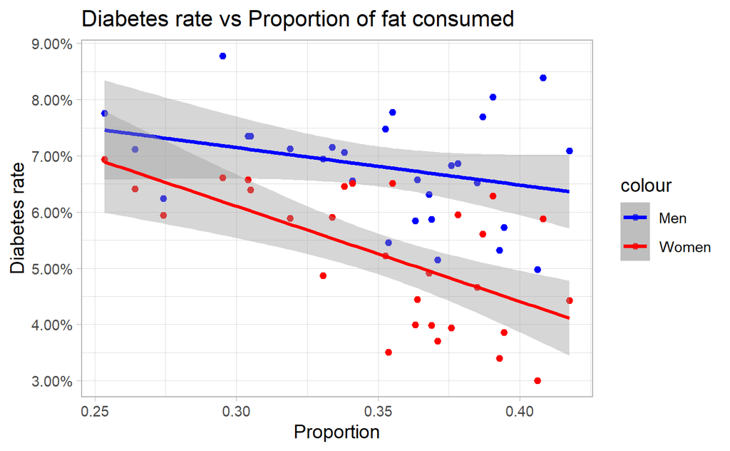

The correlation coefficients at the beginning of the question also showed us that there’s a negative relationship : -0.303 and -0.621 respectively for diabetes rates in men and women, in regards to the proportion of fat consumed. Let’s see what happens when we try to fit linear models.

|  | Diabetes rate for men vs proportion of calories from fat |  |  |  |
| --- | --- | --- | --- | --- |
| Predictors | Estimates | std. Error | Statistic | p |
| (Intercept) | 0.09 | 0.01 | 6.40 | **<0.001** |
| proportion fat | -0.07 | 0.04 | -1.65 | 0.110 |
| Observations | 29 |  |  |  |
| R<sup>2</sup> / R<sup>2</sup> adjusted | 0.092 / 0.058 |  |  |  |

|  | Diabetes rate for women vs proportion of calories from fat |  |  |  |
| --- | --- | --- | --- | --- |
| Predictors | Estimates | std. Error | Statistic | p |
| (Intercept) | 0.11 | 0.01 | 7.68 | **<0.001** |
| proportion fat | -0.17 | 0.04 | -4.12 | **<0.001** |
| Observations | 29 |  |  |  |
| R<sup>2</sup> / R<sup>2</sup> adjusted | 0.386 / 0.363 |  |  |  |

The parameter for fat is highly significant for women even though it only causes a little decrease to the diabetes rate. Are these results replicated in the clusters ?

**Correlation for cluster 1**

| Between men diabetes rate and proportion of calories from fat | 0.016 |
| --- | --- |
| Between women diabetes rate and proportion of calories from fat | -0.197 |

|  | Diabetes rate for men vs proportion of calories from fat |  |  |  |
| --- | --- | --- | --- | --- |
| Predictors | Estimates | std. Error | Statistic | p |
| (Intercept) | 0.06 | 0.04 | 1.68 | 0.128 |
| proportion fat | 0.00 | 0.09 | 0.05 | 0.962 |
| Observations | 11 |  |  |  |
| R<sup>2</sup> / R<sup>2</sup> adjusted | 0.000 / -0.111 |  |  |  |

|  | Diabetes rate for women vs proportion of calories from fat |  |  |  |
| --- | --- | --- | --- | --- |
| Predictors | Estimates | std. Error | Statistic | p |
| (Intercept) | 0.06 | 0.03 | 2.08 | 0.067 |
| proportion fat | -0.05 | 0.08 | -0.60 | 0.562 |
| Observations | 11 |  |  |  |
| R<sup>2</sup> / R<sup>2</sup> adjusted | 0.039 / -0.068 |  |  |  |

**Correlation for cluster 2**

| Between men diabetes rate and proportion of calories from fat | 0.261 |
| --- | --- |
| Between women diabetes rate and proportion of calories from fat | -0.508 |

|  | Diabetes rate for men vs proportion of calories from fat |  |  |  |
| --- | --- | --- | --- | --- |
| Predictors | Estimates | std. Error | Statistic | p |
| (Intercept) | 0.06 | 0.01 | 5.19 | **<0.001** |
| proportion fat | 0.04 | 0.04 | 1.01 | 0.329 |
| Observations | 16 |  |  |  |
| R<sup>2</sup> / R<sup>2</sup> adjusted | 0.068 / 0.001 |  |  |  |

|  | Diabetes rate for women vs proportion of calories from fat |  |  |  |
| --- | --- | --- | --- | --- |
| Predictors | Estimates | std. Error | Statistic | p |
| (Intercept) | 0.08 | 0.01 | 10.68 | **<0.001** |
| proportion fat | -0.05 | 0.02 | -2.21 | **0.044** |
| Observations | 16 |  |  |  |
| R<sup>2</sup> / R<sup>2</sup> adjusted | 0.258 / 0.205 |  |  |  |

**Correlation for cluster 3**

| Between men diabetes rate and proportion of calories from fat | -1 |
| --- | --- |
| Between women diabetes rate and proportion of calories from fat | -1 |

|  | Diabetes rate for men vs proportion of calories from fat |  |  |  |
| --- | --- | --- | --- | --- |
| Predictors | Estimates | std. Error | Statistic | p |
| (Intercept) | 0.30 | NaN | NaN | NaN |
| proportion fat | -0.61 | NaN | NaN | NaN |
| Observations | 2 |  |  |  |
| R<sup>2</sup> / R<sup>2</sup> adjusted | 1.000 / NaN |  |  |  |

|  | Diabetes rate for women vs proportion of calories from fat |  |  |  |
| --- | --- | --- | --- | --- |
| Predictors | Estimates | std. Error | Statistic | p |
| (Intercept) | 0.16 | NaN | NaN | NaN |
| proportion fat | -0.31 | NaN | NaN | NaN |
| Observations | 2 |  |  |  |
| R<sup>2</sup> / R<sup>2</sup> adjusted | 1.000 / NaN |  |  |  |

By observing the cluster plot, we can say that there’s a negative relationship between the proportion of fat consumed and diabetes prevalence within each cluster. In our results however that is not the case for the correlation with the diabetes rate in men for cluster 1 and 2, although they are weak. Otherwise, the results are in line with our expectations, but these are at most moderately strong relationships. Our regression results are also not very significant for every cluster.

Here, even though they are not sufficiently solid enough, we are surprised by our results because fatty foods are not good for diabetes, and our data shows that consuming more fat is not necessarily related to lower diabetes.